# MachineLearning

Carlos Grande Nuñez, Veronica Gomez Gomez y Pablo Olmos Martinez

13/02/2020

# Requisitos previos

# Descripcion de las variables

- id: valor único (Primary key).
- date: fecha de venta de la vivienda.
- price: precio de venta. Variable seleccionada para la aplicación del modelo y su posterior predicción.
- bedrooms: número de habitaciones por vivienda.
- bathrooms: número de baños por vivienda.
- sqft_living: superficie de la vivienda en pies cuadrados (superficie escriturada).
- sqft_lot: superficie de la parcela de la vivienda en pies cuadrados (superficie parcelaria).
- floors: número de plantas por vivienda.
- waterfront: si la vivienda tiene vistas al mar.
- view: el número de veces que se ha visitado la vivienda desde su puesta en venta.
- condition*: el estado de la vivienda establecido mediante una variable numérica del 1 al 5.
- grade*: nota general de la vivienda propuesta por el sistema de puntuación de la zona del 1 al 13.
- sqft_above: superficie de la huella perimetral de la vivienda sobre rasante en pies cuadrados.
- sqft_basement: superficie de la vivienda bajo rasante en piés cuadrados
- yr_built: año de construcción de la vivienda
- yr_renovated: año de la renovación de la vivienda. En caso de no haber sido renovada este parámetro se ha igualado a 0.
- zipcode: codigo postal de la vivienda.
- lat: latitud de la coordenada de la vivienda medida en pies.
- long: longitud de la coordenada de la vivienda medida en pies.
- sqft_living15: superficie de la vivienda en el año 2015 (admite renovaciones).
- sqft_lot15: superficie de la parcela en el año 2015 (admite modificaciones)

# Estudio de la variable price

Consideramos interesante analizar la variable price antes de crear los clusters. Ya que en principio buscamos crear clusters en funcion del precio de las viviendas y sus caracteristicas.

```r
#Obtención de variables cuantitativas
df_cuantitativas = df_root %>% select(3, 6, 7, 13:16, 18:dim(df_root)[2])

data.frame(variable = names(df_cuantitativas),
           classe = sapply(df_cuantitativas, typeof),
           first_values = sapply(df_cuantitativas, function(x) paste0(head(x),  collapse = ", ")),
           row.names = NULL) %>% kable() %>% kable_styling()
```

| variable | classe | first_values |
| --- | --- | --- |
| price | double | 221900, 538000, 180000, 604000, 510000, 1230000 |
| sqft_living | integer | 1180, 2570, 770, 1960, 1680, 5420 |
| sqft_lot | integer | 5650, 7242, 10000, 5000, 8080, 101930 |
| sqft_above | integer | 1180, 2170, 770, 1050, 1680, 3890 |
| sqft_basement | integer | 0, 400, 0, 910, 0, 1530 |
| yr_built | integer | 1955, 1951, 1933, 1965, 1987, 2001 |
| yr_renovated | integer | 0, 1991, 0, 0, 0, 0 |
| lat | double | 47.5112, 47.721, 47.7379, 47.5208, 47.6168, 47.6561 |
| long | double | -122.257, -122.319, -122.233, -122.393, -122.045, -122.005 |
| sqft_living15 | integer | 1340, 1690, 2720, 1360, 1800, 4760 |
| sqft_lot15 | integer | 5650, 7639, 8062, 5000, 7503, 101930 |

```r
var_price = df_cuantitativas$price
name = "price"

# Descripción de la variable
describe(var_price)
```

```
## var_price
##        n  missing distinct     Info     Mean      Gmd      .05      .10
##    21597        0     3622        1   540297   329526   210000   245000
##      .25      .50      .75      .90      .95
##   322000   450000   645000   887000  1160000
##
## lowest :   78000   80000   81000   82000   82500
## highest: 5350000 5570000 6890000 7060000 7700000
```

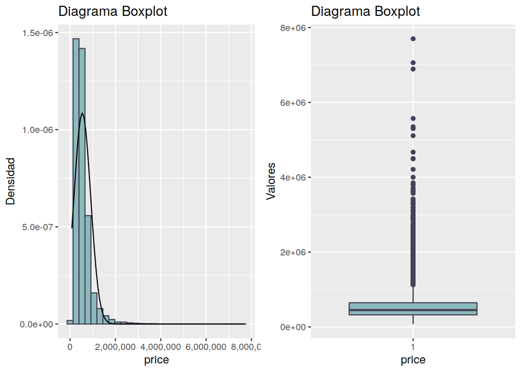

```r
# Visualización de la variable
p1 <- phist(df_cuantitativas, ., name)
p2 <- pbox(var_price, name)
grid.arrange(p1, p2, nrow=1)
```

Se puede observar que la variable “price” no sigue una distribucion normal y como se muestra en el diagrama de caja cuenta con bastantes valores de tipo outliar.

Las posibles alternativas para transformar la variable serian:  
- Transformacion logaritmico 10  
- Raiz cuadrada  
- Inversa 1/x

# Analisis EDA de los clusters

Para esta parte de la memoria se trabajara sobre un data set ya dividido en clusters. Los clusters sobre los que se trabajara son los obtenidos de la memoria anterior.

```r
df_clusters <- read.csv(file="./cluster.csv")
```

## Resumen Cluster 1

```r
cluster_1 = filter(df_clusters, cluster == "1")

#Muestra de las primeras 5 filas de la base de datos
kable(head(cluster_1)) %>%
  kable_styling() %>%
  scroll_box(width = "100%", height = TRUE)
```

| X.2 | X.1 | X | Y | id | date | price | bedrooms | bathrooms | sqft_living | sqft_lot | floors | waterfront | view | condition | grade | sqft_above | sqft_basement | yr_built | yr_renovated | zipcode | lat | long | sqft_living15 | sqft_lot15 | cluster | hclust | Cluster_final |
| --- | --- | --- | --- | --- | --- | --- | --- | --- | --- | --- | --- | --- | --- | --- | --- | --- | --- | --- | --- | --- | --- | --- | --- | --- | --- | --- | --- |
| 1 | 1 | 3.762164 | 22.445021 | 7129300520 | 10/13/2014 | 221900 | 3 | 1.00 | 1180 | 5650 | 1 | 0 | 0 | 3 | 7 | 1180 | 0 | 1955 | 0 | 98178 | 47.5112 | -122.257 | 1340 | 5650 | 1 | 1 | low |
| 2 | 2 | -24.035975 | 9.766915 | 6414100192 | 12/9/2014 | 538000 | 3 | 2.25 | 2570 | 7242 | 2 | 0 | 0 | 3 | 7 | 2170 | 400 | 1951 | 1991 | 98125 | 47.7210 | -122.319 | 1690 | 7639 | 1 | 2 | top |
| 3 | 3 | 5.217015 | 8.102678 | 5631500400 | 2/25/2015 | 180000 | 2 | 1.00 | 770 | 10000 | 1 | 0 | 0 | 3 | 6 | 770 | 0 | 1933 | 0 | 98028 | 47.7379 | -122.233 | 2720 | 8062 | 1 | 3 | med |
| 8 | 8 | -6.729073 | 9.258931 | 2008000270 | 1/15/2015 | 291850 | 3 | 1.50 | 1060 | 9711 | 1 | 0 | 0 | 3 | 7 | 1060 | 0 | 1963 | 0 | 98198 | 47.4095 | -122.315 | 1650 | 9711 | 1 | 6 | med |
| 9 | 9 | -4.357549 | 8.894489 | 2414600126 | 4/15/2015 | 229500 | 3 | 1.00 | 1780 | 7470 | 1 | 0 | 0 | 3 | 7 | 1050 | 730 | 1960 | 0 | 98146 | 47.5123 | -122.337 | 1780 | 8113 | 1 | 6 | med |
| 12 | 12 | -1.447507 | 22.543121 | 9212900260 | 5/27/2014 | 468000 | 2 | 1.00 | 1160 | 6000 | 1 | 0 | 0 | 4 | 7 | 860 | 300 | 1942 | 0 | 98115 | 47.6900 | -122.292 | 1330 | 6000 | 1 | 1 | low |

```r
#Tabla resumen con los principales estadísticos
kable(summary(cluster_1)) %>%
  kable_styling() %>%
  scroll_box(width = "100%", height = TRUE)
```

|  | X.2 | X.1 | X | Y | id | date | price | bedrooms | bathrooms | sqft_living | sqft_lot | floors | waterfront | view | condition | grade | sqft_above | sqft_basement | yr_built | yr_renovated | zipcode | lat | long | sqft_living15 | sqft_lot15 | cluster | hclust | Cluster_final |
| --- | --- | --- | --- | --- | --- | --- | --- | --- | --- | --- | --- | --- | --- | --- | --- | --- | --- | --- | --- | --- | --- | --- | --- | --- | --- | --- | --- | --- |
|  | Min. : 1 | Min. : 1 | Min. :-29.5458 | Min. :-13.72 | Min. :1.200e+06 | 4/22/2015: 71 | Min. : 78000 | Min. : 1.000 | Min. :0.500 | Min. : 370 | Min. : 520 | Min. :1.00 | Min. :0.00000 | Min. :0.0000 | Min. :1.00 | Min. : 4.000 | Min. : 370 | Min. : 0.0 | Min. :1900 | Min. : 0 | Min. :98003 | Min. :47.19 | Min. :-122.5 | Min. : 460 | Min. : 659 | Min. :1 | Min. :1.000 | low:4511 |
|  | 1st Qu.: 4852 | 1st Qu.: 4852 | 1st Qu.: -9.1080 | 1st Qu.: 10.24 | 1st Qu.:2.594e+09 | 6/23/2014: 50 | 1st Qu.: 328000 | 1st Qu.: 2.000 | 1st Qu.:1.000 | 1st Qu.: 1170 | 1st Qu.: 4600 | 1st Qu.:1.00 | 1st Qu.:0.00000 | 1st Qu.:0.0000 | 1st Qu.:3.00 | 1st Qu.: 7.000 | 1st Qu.:1000 | 1st Qu.: 0.0 | 1st Qu.:1925 | 1st Qu.: 0 | 1st Qu.:98109 | 1st Qu.:47.55 | 1st Qu.:-122.4 | 1st Qu.:1330 | 1st Qu.: 4650 | 1st Qu.:1 | 1st Qu.:1.000 | med:2198 |
|  | Median : 9940 | Median : 9940 | Median : -3.8976 | Median : 15.51 | Median :4.443e+09 | 3/4/2015 : 49 | Median : 439888 | Median : 3.000 | Median :1.750 | Median : 1570 | Median : 6200 | Median :1.00 | Median :0.00000 | Median :0.0000 | Median :3.00 | Median : 7.000 | Median :1240 | Median : 160.0 | Median :1946 | Median : 0 | Median :98119 | Median :47.65 | Median :-122.3 | Median :1580 | Median : 6120 | Median :1 | Median :1.000 | top: 546 |
|  | Mean : 9979 | Mean : 9979 | Mean : -5.2781 | Mean : 14.96 | Mean :4.927e+09 | 4/27/2015: 49 | Mean : 498294 | Mean : 3.111 | Mean :1.663 | Mean : 1679 | Mean : 7835 | Mean :1.22 | Mean :0.00634 | Mean :0.2571 | Mean :3.47 | Mean : 7.065 | Mean :1314 | Mean : 365.1 | Mean :1944 | Mean : 140 | Mean :98126 | Mean :47.63 | Mean :-122.3 | Mean :1660 | Mean : 7102 | Mean :1 | Mean :2.469 | NA |
|  | 3rd Qu.:14921 | 3rd Qu.:14921 | 3rd Qu.: 0.4877 | 3rd Qu.: 21.23 | 3rd Qu.:7.519e+09 | 4/28/2015: 48 | 3rd Qu.: 599000 | 3rd Qu.: 4.000 | 3rd Qu.:2.000 | 3rd Qu.: 2060 | 3rd Qu.: 8361 | 3rd Qu.:1.50 | 3rd Qu.:0.00000 | 3rd Qu.:0.0000 | 3rd Qu.:4.00 | 3rd Qu.: 7.000 | 3rd Qu.:1540 | 3rd Qu.: 700.0 | 3rd Qu.:1957 | 3rd Qu.: 0 | 3rd Qu.:98146 | 3rd Qu.:47.70 | 3rd Qu.:-122.3 | 3rd Qu.:1900 | 3rd Qu.: 8160 | 3rd Qu.:1 | 3rd Qu.:3.000 | NA |
|  | Max. :21568 | Max. :21568 | Max. : 27.0533 | Max. : 30.13 | Max. :9.900e+09 | 5/20/2014: 45 | Max. :7700000 | Max. :33.000 | Max. :8.000 | Max. :12050 | Max. :1164794 | Max. :3.00 | Max. :1.00000 | Max. :4.0000 | Max. :5.00 | Max. :13.000 | Max. :8570 | Max. :3480.0 | Max. :2015 | Max. :2015 | Max. :98199 | Max. :47.78 | Max. :-121.3 | Max. :4950 | Max. :168141 | Max. :1 | Max. :9.000 | NA |
|  | NA | NA | NA | NA | NA | (Other) :6943 | NA | NA | NA | NA | NA | NA | NA | NA | NA | NA | NA | NA | NA | NA | NA | NA | NA | NA | NA | NA | NA | NA |

## Resumen Cluster 2

```r
cluster_2 = filter(df_clusters, cluster == "2")

#Muestra de las primeras 5 filas de la base de datos
kable(head(cluster_2)) %>%
  kable_styling() %>%
  scroll_box(width = "100%", height = TRUE)
```

| X.2 | X.1 | X | Y | id | date | price | bedrooms | bathrooms | sqft_living | sqft_lot | floors | waterfront | view | condition | grade | sqft_above | sqft_basement | yr_built | yr_renovated | zipcode | lat | long | sqft_living15 | sqft_lot15 | cluster | hclust | Cluster_final |
| --- | --- | --- | --- | --- | --- | --- | --- | --- | --- | --- | --- | --- | --- | --- | --- | --- | --- | --- | --- | --- | --- | --- | --- | --- | --- | --- | --- |
| 4 | 4 | 7.588730 | 18.9677302 | 2487200875 | 12/9/2014 | 604000 | 4 | 3.00 | 1960 | 5000 | 1.0 | 0 | 0 | 5 | 7 | 1050 | 910 | 1965 | 0 | 98136 | 47.5208 | -122.393 | 1360 | 5000 | 2 | 1 | low |
| 11 | 11 | 8.887572 | -0.5260397 | 1736800520 | 4/3/2015 | 662500 | 3 | 2.50 | 3560 | 9796 | 1.0 | 0 | 0 | 3 | 8 | 1860 | 1700 | 1965 | 0 | 98007 | 47.6007 | -122.145 | 2210 | 8925 | 2 | 3 | med |
| 13 | 13 | 7.524406 | 7.9397305 | 114101516 | 5/28/2014 | 310000 | 3 | 1.00 | 1430 | 19901 | 1.5 | 0 | 0 | 4 | 7 | 1430 | 0 | 1927 | 0 | 98028 | 47.7558 | -122.229 | 1780 | 12697 | 2 | 3 | med |
| 14 | 14 | 3.280744 | -0.2579687 | 6054650070 | 10/7/2014 | 400000 | 3 | 1.75 | 1370 | 9680 | 1.0 | 0 | 0 | 4 | 7 | 1370 | 0 | 1977 | 0 | 98074 | 47.6127 | -122.045 | 1370 | 10208 | 2 | 3 | med |
| 19 | 19 | 21.210822 | 4.3326556 | 16000397 | 12/5/2014 | 189000 | 2 | 1.00 | 1200 | 9850 | 1.0 | 0 | 0 | 4 | 7 | 1200 | 0 | 1921 | 0 | 98002 | 47.3089 | -122.210 | 1060 | 5095 | 2 | 9 | low |
| 20 | 20 | 24.047693 | 1.6754393 | 7983200060 | 4/24/2015 | 230000 | 3 | 1.00 | 1250 | 9774 | 1.0 | 0 | 0 | 4 | 7 | 1250 | 0 | 1969 | 0 | 98003 | 47.3343 | -122.306 | 1280 | 8850 | 2 | 9 | low |

```r
#Tabla resumen con los principales estadísticos
kable(summary(cluster_2)) %>%
  kable_styling() %>%
  scroll_box(width = "100%", height = TRUE)
```

|  | X.2 | X.1 | X | Y | id | date | price | bedrooms | bathrooms | sqft_living | sqft_lot | floors | waterfront | view | condition | grade | sqft_above | sqft_basement | yr_built | yr_renovated | zipcode | lat | long | sqft_living15 | sqft_lot15 | cluster | hclust | Cluster_final |
| --- | --- | --- | --- | --- | --- | --- | --- | --- | --- | --- | --- | --- | --- | --- | --- | --- | --- | --- | --- | --- | --- | --- | --- | --- | --- | --- | --- | --- |
|  | Min. : 4 | Min. : 4 | Min. :-30.601 | Min. :-25.841 | Min. :1.200e+06 | 9/29/2014: 52 | Min. : 85000 | Min. :1.000 | Min. :0.750 | Min. : 440 | Min. : 1500 | Min. :1.000 | Min. :0.000000 | Min. :0.0000 | Min. :1.000 | Min. : 3.00 | Min. : 440 | Min. : 0 | Min. :1900 | Min. : 0.00 | Min. :98001 | Min. :47.16 | Min. :-122.5 | Min. : 399 | Min. : 1566 | Min. :2 | Min. :1.000 | low:3201 |
|  | 1st Qu.: 4898 | 1st Qu.: 4898 | 1st Qu.: 6.377 | 1st Qu.: -1.861 | 1st Qu.:1.796e+09 | 6/26/2014: 45 | 1st Qu.: 253000 | 1st Qu.:3.000 | 1st Qu.:1.500 | 1st Qu.:1340 | 1st Qu.: 7727 | 1st Qu.:1.000 | 1st Qu.:0.000000 | 1st Qu.:0.0000 | 1st Qu.:3.000 | 1st Qu.: 7.00 | 1st Qu.:1170 | 1st Qu.: 0 | 1st Qu.:1960 | 1st Qu.: 0.00 | 1st Qu.:98010 | 1st Qu.:47.36 | 1st Qu.:-122.2 | 1st Qu.:1480 | 1st Qu.: 7760 | 1st Qu.:2 | 1st Qu.:3.000 | med:2220 |
|  | Median : 9723 | Median : 9723 | Median : 13.039 | Median : 1.601 | Median :3.343e+09 | 4/14/2015: 42 | Median : 335000 | Median :3.000 | Median :1.750 | Median :1700 | Median : 9600 | Median :1.000 | Median :0.000000 | Median :0.0000 | Median :4.000 | Median : 7.00 | Median :1370 | Median : 0 | Median :1968 | Median : 0.00 | Median :98033 | Median :47.46 | Median :-122.2 | Median :1760 | Median : 9259 | Median :2 | Median :9.000 | top: 266 |
|  | Mean : 9788 | Mean : 9788 | Mean : 11.257 | Mean : 1.443 | Mean :4.085e+09 | 3/25/2015: 39 | Mean : 412375 | Mean :3.345 | Mean :1.851 | Mean :1808 | Mean : 20087 | Mean :1.068 | Mean :0.006682 | Mean :0.1721 | Mean :3.775 | Mean : 7.19 | Mean :1452 | Mean : 356 | Mean :1968 | Mean : 62.75 | Mean :98039 | Mean :47.48 | Mean :-122.2 | Mean :1843 | Mean : 16873 | Mean :2 | Mean :6.233 | NA |
|  | 3rd Qu.:14698 | 3rd Qu.:14698 | 3rd Qu.: 18.967 | 3rd Qu.: 5.016 | 3rd Qu.:6.448e+09 | 7/15/2014: 36 | 3rd Qu.: 495100 | 3rd Qu.:4.000 | 3rd Qu.:2.250 | 3rd Qu.:2140 | 3rd Qu.: 13383 | 3rd Qu.:1.000 | 3rd Qu.:0.000000 | 3rd Qu.:0.0000 | 3rd Qu.:4.000 | 3rd Qu.: 8.00 | 3rd Qu.:1660 | 3rd Qu.: 680 | 3rd Qu.:1978 | 3rd Qu.: 0.00 | 3rd Qu.:98055 | 3rd Qu.:47.60 | 3rd Qu.:-122.1 | 3rd Qu.:2120 | 3rd Qu.: 12000 | 3rd Qu.:2 | 3rd Qu.:9.000 | NA |
|  | Max. :21587 | Max. :21587 | Max. : 27.537 | Max. : 28.187 | Max. :9.836e+09 | 6/23/2014: 35 | Max. :3800000 | Max. :8.000 | Max. :5.500 | Max. :7050 | Max. :1651359 | Max. :2.500 | Max. :1.000000 | Max. :4.0000 | Max. :5.000 | Max. :13.00 | Max. :5450 | Max. :2850 | Max. :2014 | Max. :2015.00 | Max. :98199 | Max. :47.78 | Max. :-121.3 | Max. :5070 | Max. :425581 | Max. :2 | Max. :9.000 | NA |
|  | NA | NA | NA | NA | NA | (Other) :5438 | NA | NA | NA | NA | NA | NA | NA | NA | NA | NA | NA | NA | NA | NA | NA | NA | NA | NA | NA | NA | NA | NA |

## Resumen Cluster 3

```r
cluster_3 = filter(df_clusters, cluster == "3")

#Muestra de las primeras 5 filas de la base de datos
kable(head(cluster_3)) %>%
  kable_styling() %>%
  scroll_box(width = "100%", height = TRUE)
```

| X.2 | X.1 | X | Y | id | date | price | bedrooms | bathrooms | sqft_living | sqft_lot | floors | waterfront | view | condition | grade | sqft_above | sqft_basement | yr_built | yr_renovated | zipcode | lat | long | sqft_living15 | sqft_lot15 | cluster | hclust | Cluster_final |
| --- | --- | --- | --- | --- | --- | --- | --- | --- | --- | --- | --- | --- | --- | --- | --- | --- | --- | --- | --- | --- | --- | --- | --- | --- | --- | --- | --- |
| 5 | 5 | 0.6661815 | 3.939548 | 1954400510 | 2/18/2015 | 510000 | 3 | 2.00 | 1680 | 8080 | 1 | 0 | 0 | 3 | 8 | 1680 | 0 | 1987 | 0 | 98074 | 47.6168 | -122.045 | 1800 | 7503 | 3 | 3 | med |
| 6 | 6 | -2.6542516 | -26.720289 | 7237550310 | 5/12/2014 | 1230000 | 4 | 4.50 | 5420 | 101930 | 1 | 0 | 0 | 3 | 11 | 3890 | 1530 | 2001 | 0 | 98053 | 47.6561 | -122.005 | 4760 | 101930 | 3 | 4 | med |
| 7 | 7 | 15.5619202 | -13.926208 | 1321400060 | 6/27/2014 | 257500 | 3 | 2.25 | 1715 | 6819 | 2 | 0 | 0 | 3 | 7 | 1715 | 0 | 1995 | 0 | 98003 | 47.3097 | -122.327 | 2238 | 6819 | 3 | 5 | low |
| 10 | 10 | 10.7133501 | -16.620758 | 3793500160 | 3/12/2015 | 323000 | 3 | 2.50 | 1890 | 6560 | 2 | 0 | 0 | 3 | 7 | 1890 | 0 | 2003 | 0 | 98038 | 47.3684 | -122.031 | 2390 | 7570 | 3 | 5 | low |
| 16 | 16 | -12.5938270 | -1.704118 | 9297300055 | 1/24/2015 | 650000 | 4 | 3.00 | 2950 | 5000 | 2 | 0 | 3 | 3 | 9 | 1980 | 970 | 1979 | 0 | 98126 | 47.5714 | -122.375 | 2140 | 4000 | 3 | 7 | med |
| 17 | 17 | -4.2251162 | -8.982526 | 1875500060 | 7/31/2014 | 395000 | 3 | 2.00 | 1890 | 14040 | 2 | 0 | 0 | 3 | 7 | 1890 | 0 | 1994 | 0 | 98019 | 47.7277 | -121.962 | 1890 | 14018 | 3 | 8 | top |

```r
#Tabla resumen con los principales estadísticos
kable(summary(cluster_3)) %>%
  kable_styling() %>%
  scroll_box(width = "100%", height = TRUE)
```

|  | X.2 | X.1 | X | Y | id | date | price | bedrooms | bathrooms | sqft_living | sqft_lot | floors | waterfront | view | condition | grade | sqft_above | sqft_basement | yr_built | yr_renovated | zipcode | lat | long | sqft_living15 | sqft_lot15 | cluster | hclust | Cluster_final |
| --- | --- | --- | --- | --- | --- | --- | --- | --- | --- | --- | --- | --- | --- | --- | --- | --- | --- | --- | --- | --- | --- | --- | --- | --- | --- | --- | --- | --- |
|  | Min. : 5 | Min. : 5 | Min. :-30.476 | Min. :-28.849 | Min. :1.000e+06 | 7/7/2014 : 60 | Min. : 139500 | Min. : 1.000 | Min. :0.500 | Min. : 750 | Min. : 572 | Min. :1.000 | Min. :0.000000 | Min. :0.000 | Min. :2.000 | Min. : 5.000 | Min. : 630 | Min. : 0 | Min. :1900 | Min. : 0.0 | Min. :98001 | Min. :47.16 | Min. :-122.5 | Min. : 700 | Min. : 651 | Min. :3 | Min. :1.000 | low:2258 |
|  | 1st Qu.: 6276 | 1st Qu.: 6276 | 1st Qu.:-11.622 | 1st Qu.:-20.064 | 1st Qu.:2.099e+09 | 4/27/2015: 59 | 1st Qu.: 393250 | 1st Qu.: 3.000 | 1st Qu.:2.500 | 1st Qu.: 1900 | 1st Qu.: 4440 | 1st Qu.:2.000 | 1st Qu.:0.000000 | 1st Qu.:0.000 | 1st Qu.:3.000 | 1st Qu.: 8.000 | 1st Qu.:1790 | 1st Qu.: 0 | 1st Qu.:1989 | 1st Qu.: 0.0 | 1st Qu.:98030 | 1st Qu.:47.48 | 1st Qu.:-122.3 | 1st Qu.:1780 | 1st Qu.: 4600 | 1st Qu.:3 | 1st Qu.:4.000 | med:3807 |
|  | Median :12500 | Median :12500 | Median : -1.642 | Median :-14.448 | Median :3.886e+09 | 7/8/2014 : 59 | Median : 549900 | Median : 4.000 | Median :2.500 | Median : 2460 | Median : 7200 | Median :2.000 | Median :0.000000 | Median :0.000 | Median :3.000 | Median : 8.000 | Median :2330 | Median : 0 | Median :2000 | Median : 0.0 | Median :98053 | Median :47.57 | Median :-122.2 | Median :2280 | Median : 7203 | Median :3 | Median :5.000 | top:2590 |
|  | Mean :12151 | Mean :12151 | Mean : -2.973 | Mean :-13.486 | Mean :4.615e+09 | 6/17/2014: 57 | Mean : 659559 | Mean : 3.611 | Mean :2.669 | Mean : 2595 | Mean : 17912 | Mean :2.004 | Mean :0.009128 | Mean :0.256 | Mean :3.119 | Mean : 8.463 | Mean :2407 | Mean : 188 | Mean :1996 | Mean : 52.2 | Mean :98063 | Mean :47.56 | Mean :-122.2 | Mean :2354 | Mean : 14796 | Mean :3 | Mean :5.886 | NA |
|  | 3rd Qu.:18776 | 3rd Qu.:18776 | 3rd Qu.: 5.816 | 3rd Qu.: -8.763 | 3rd Qu.:7.504e+09 | 6/23/2014: 57 | 3rd Qu.: 768000 | 3rd Qu.: 4.000 | 3rd Qu.:2.750 | 3rd Qu.: 3120 | 3rd Qu.: 11695 | 3rd Qu.:2.000 | 3rd Qu.:0.000000 | 3rd Qu.:0.000 | 3rd Qu.:3.000 | 3rd Qu.: 9.000 | 3rd Qu.:2900 | 3rd Qu.: 0 | 3rd Qu.:2006 | 3rd Qu.: 0.0 | 3rd Qu.:98092 | 3rd Qu.:47.67 | 3rd Qu.:-122.0 | 3rd Qu.:2810 | 3rd Qu.: 10956 | 3rd Qu.:3 | 3rd Qu.:8.000 | NA |
|  | Max. :21597 | Max. :21597 | Max. : 27.464 | Max. : 27.127 | Max. :9.895e+09 | 6/20/2014: 55 | Max. :7060000 | Max. :11.000 | Max. :8.000 | Max. :13540 | Max. :1024068 | Max. :3.500 | Max. :1.000000 | Max. :4.000 | Max. :5.000 | Max. :13.000 | Max. :9410 | Max. :4820 | Max. :2015 | Max. :2015.0 | Max. :98199 | Max. :47.78 | Max. :-121.4 | Max. :6210 | Max. :871200 | Max. :3 | Max. :9.000 | NA |
|  | NA | NA | NA | NA | NA | (Other) :8308 | NA | NA | NA | NA | NA | NA | NA | NA | NA | NA | NA | NA | NA | NA | NA | NA | NA | NA | NA | NA | NA | NA |

### A. Análisis univariante cuantitativo

```r
#Obtención de variables cuantitativas
df_cuantitativas_clusters = df_clusters%>% select(3, 6, 7, 13:16, 18:dim(df_clusters)[2])

data.frame(variable = names(df_cuantitativas_clusters),
           classe = sapply(df_cuantitativas_clusters, typeof),
           first_values = sapply(df_cuantitativas_clusters, function(x) paste0(head(x),  collapse = ", ")),
           row.names = NULL) %>% kable() %>% kable_styling()
```

| variable | classe | first_values |
| --- | --- | --- |
| X | double | 3.7621642125675, -24.0359753189715, 5.21701533117796, 7.58872965013843, 0.666181472085254, -2.65425155380627 |
| date | integer | 10/13/2014, 12/9/2014, 2/25/2015, 12/9/2014, 2/18/2015, 5/12/2014 |
| price | double | 221900, 538000, 180000, 604000, 510000, 1230000 |
| waterfront | integer | 0, 0, 0, 0, 0, 0 |
| view | integer | 0, 0, 0, 0, 0, 0 |
| condition | integer | 3, 3, 3, 5, 3, 3 |
| grade | integer | 7, 7, 6, 7, 8, 11 |
| sqft_basement | integer | 0, 400, 0, 910, 0, 1530 |
| yr_built | integer | 1955, 1951, 1933, 1965, 1987, 2001 |
| yr_renovated | integer | 0, 1991, 0, 0, 0, 0 |
| zipcode | integer | 98178, 98125, 98028, 98136, 98074, 98053 |
| lat | double | 47.5112, 47.721, 47.7379, 47.5208, 47.6168, 47.6561 |
| long | double | -122.257, -122.319, -122.233, -122.393, -122.045, -122.005 |
| sqft_living15 | integer | 1340, 1690, 2720, 1360, 1800, 4760 |
| sqft_lot15 | integer | 5650, 7639, 8062, 5000, 7503, 101930 |
| cluster | integer | 1, 1, 1, 2, 3, 3 |
| hclust | integer | 1, 2, 3, 1, 3, 4 |
| Cluster_final | integer | low, top, med, low, med, med |

**Estudio de la variable “price” (precio de venta).**

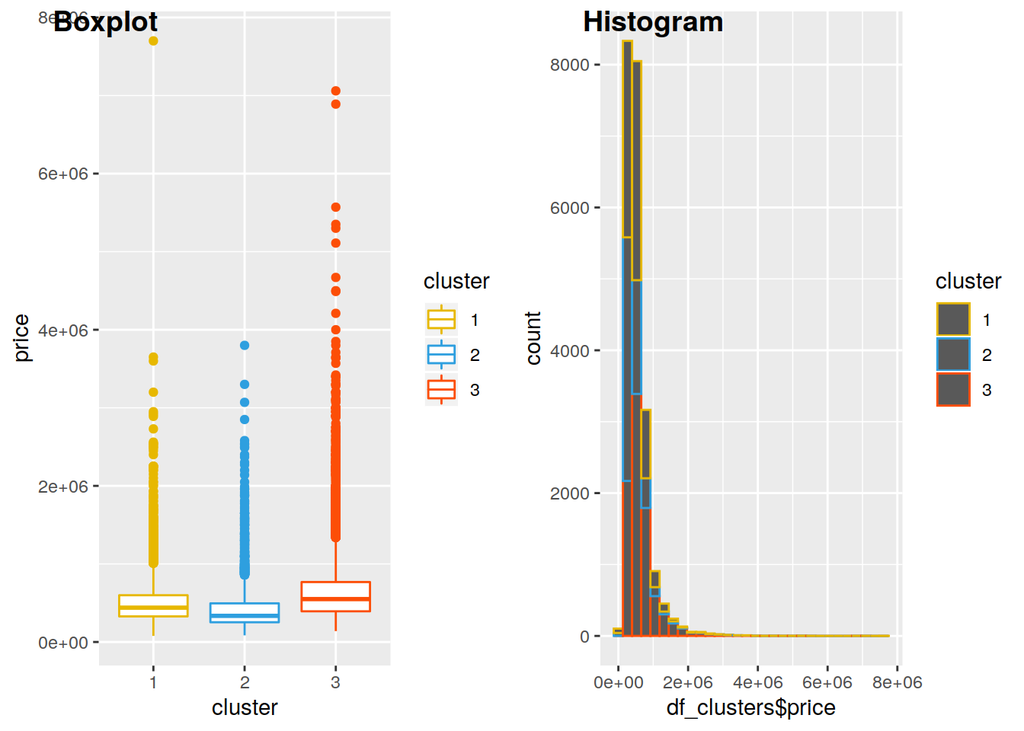

```r
my3cols <- c("#E7B800", "#2E9FDF", "#FC4E07")
df_clusters$cluster <- as.factor(df_clusters$cluster)

pBoxPlot <- ggplot(df_clusters, aes(x = cluster, y = price))
bxp <- pBoxPlot + geom_boxplot(aes(color = cluster)) +
  scale_color_manual(values = my3cols)

geomHist <- ggplot(data=df_clusters, aes(df_clusters$price))

gh <- geomHist + geom_histogram(aes(color = cluster)) +
      scale_color_manual(values = my3cols)

figure <- ggarrange(bxp, gh,
                    labels = c("Boxplot", "Histogram"),
                    ncol = 2, nrow = 1)
figure
```

**Estudio de las variables “sqft_living” y “sqft_living15” (Superficie de la vivienda).** variable “sqft_living”: superficie de la vivienda en pies cuadrados (superficie escriturada).

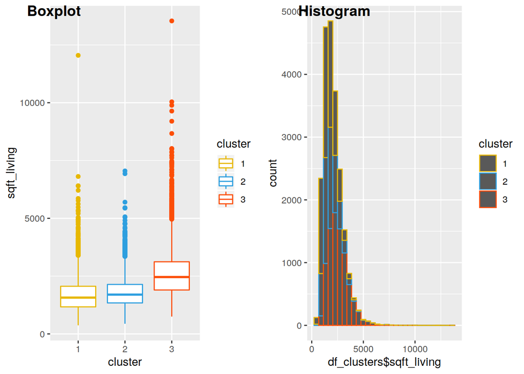

```r
my3cols <- c("#E7B800", "#2E9FDF", "#FC4E07")
df_clusters$cluster <- as.factor(df_clusters$cluster)

pBoxPlot <- ggplot(df_clusters, aes(x = cluster, y = sqft_living))
bxp <- pBoxPlot + geom_boxplot(aes(color = cluster)) +
  scale_color_manual(values = my3cols)

geomHist <- ggplot(data=df_clusters, aes(df_clusters$sqft_living))

gh <- geomHist + geom_histogram(aes(color = cluster)) +
      scale_color_manual(values = my3cols)

figure <- ggarrange(bxp, gh,
                    labels = c("Boxplot", "Histogram"),
                    ncol = 2, nrow = 1)
figure
```

variable “sqft_living15”: superficie de la vivienda en pies cuadrados (superficie escriturada).

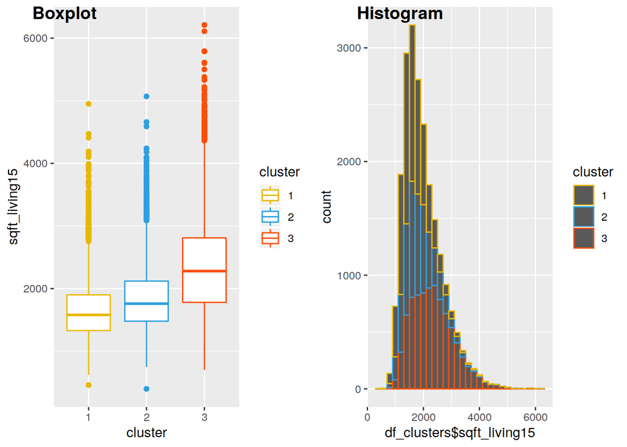

```r
my3cols <- c("#E7B800", "#2E9FDF", "#FC4E07")
df_clusters$cluster <- as.factor(df_clusters$cluster)

pBoxPlot <- ggplot(df_clusters, aes(x = cluster, y = sqft_living15))
bxp <- pBoxPlot + geom_boxplot(aes(color = cluster)) +
  scale_color_manual(values = my3cols)

geomHist <- ggplot(data=df_clusters, aes(df_clusters$sqft_living15))

gh <- geomHist + geom_histogram(aes(color = cluster)) +
      scale_color_manual(values = my3cols)

figure <- ggarrange(bxp, gh,
                    labels = c("Boxplot", "Histogram"),
                    ncol = 2, nrow = 1)
figure
```

**Estudio de las variables “sqft_lot” y "sqft_lot15 (superficie de la parcela de la vivienda).** Variables “sqft_lot”: superficie de la parcela de la vivienda en pies cuadrados (superficie parcelaria).

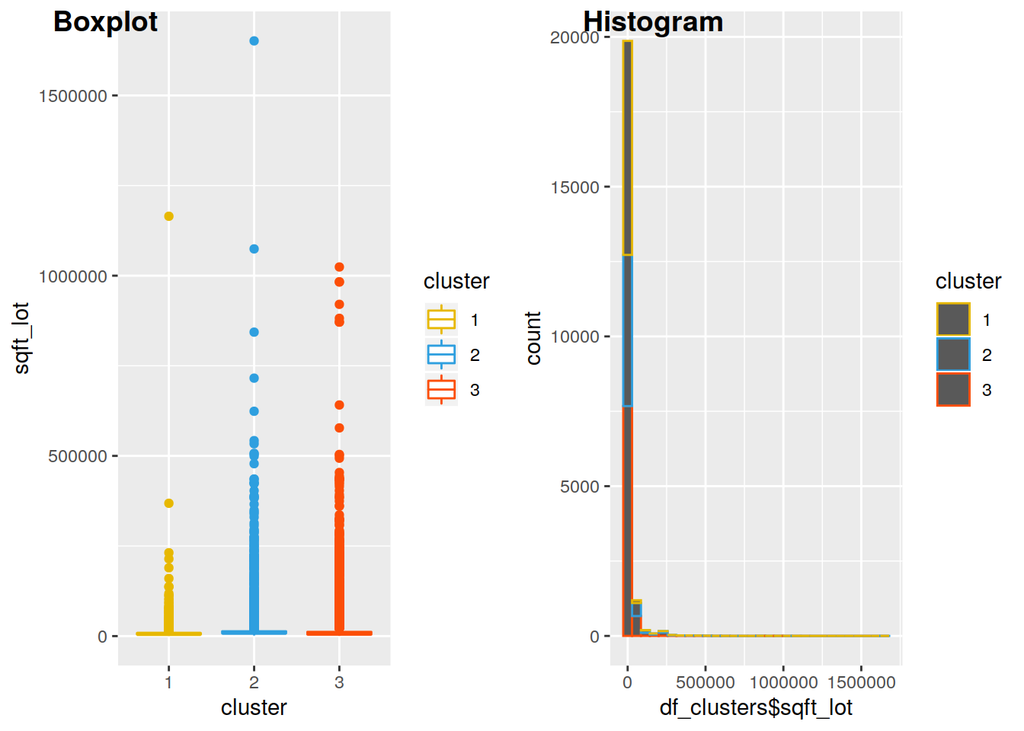

```r
my3cols <- c("#E7B800", "#2E9FDF", "#FC4E07")
df_clusters$cluster <- as.factor(df_clusters$cluster)

pBoxPlot <- ggplot(df_clusters, aes(x = cluster, y = sqft_lot))
bxp <- pBoxPlot + geom_boxplot(aes(color = cluster)) +
  scale_color_manual(values = my3cols)

geomHist <- ggplot(data=df_clusters, aes(df_clusters$sqft_lot))

gh <- geomHist + geom_histogram(aes(color = cluster)) +
      scale_color_manual(values = my3cols)

figure <- ggarrange(bxp, gh,
                    labels = c("Boxplot", "Histogram"),
                    ncol = 2, nrow = 1)
figure
```

Variable “sqft_lot15”: superficie de la parcela en el año 2015 (admite modificaciones)

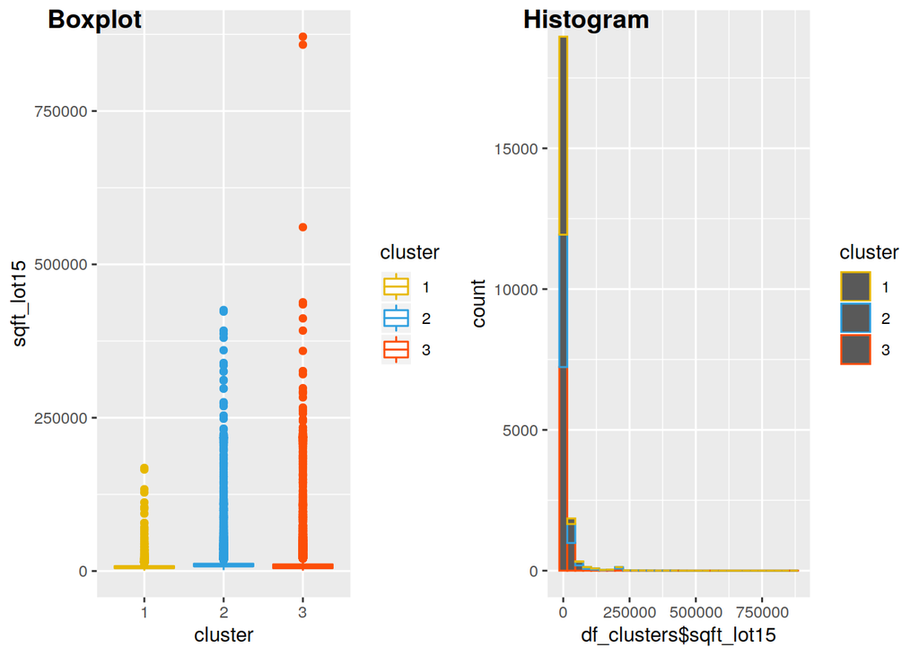

```r
my3cols <- c("#E7B800", "#2E9FDF", "#FC4E07")
df_clusters$cluster <- as.factor(df_clusters$cluster)

pBoxPlot <- ggplot(df_clusters, aes(x = cluster, y = sqft_lot15))
bxp <- pBoxPlot + geom_boxplot(aes(color = cluster)) +
  scale_color_manual(values = my3cols)

geomHist <- ggplot(data=df_clusters, aes(df_clusters$sqft_lot15))

gh <- geomHist + geom_histogram(aes(color = cluster)) +
      scale_color_manual(values = my3cols)

figure <- ggarrange(bxp, gh,
                    labels = c("Boxplot", "Histogram"),
                    ncol = 2, nrow = 1)
figure
```

**Estudio de la variable “sqft_above” (superficie de la huella de la vivienda).**

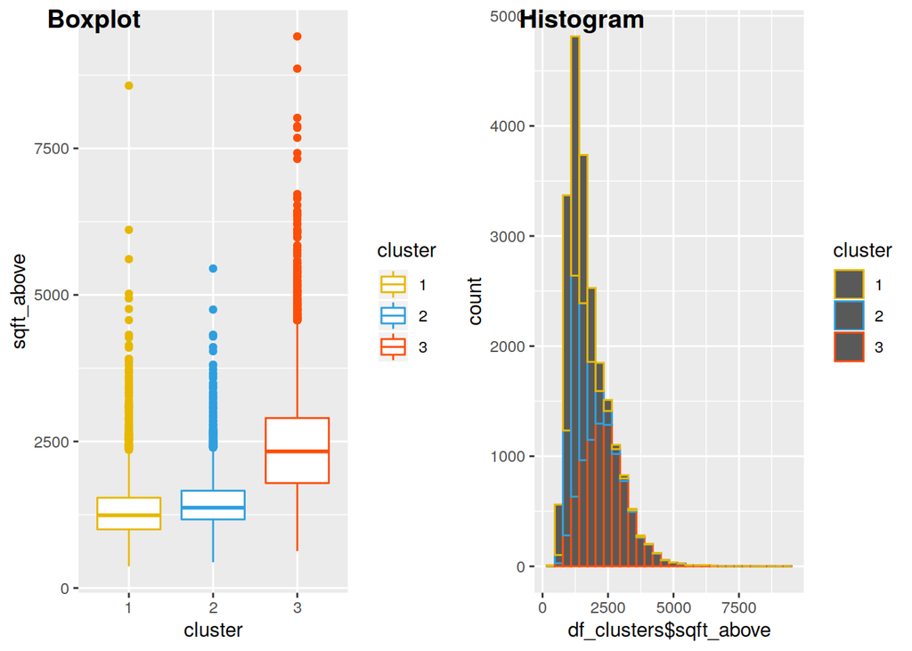

```r
my3cols <- c("#E7B800", "#2E9FDF", "#FC4E07")
df_clusters$cluster <- as.factor(df_clusters$cluster)

pBoxPlot <- ggplot(df_clusters, aes(x = cluster, y = sqft_above))
bxp <- pBoxPlot + geom_boxplot(aes(color = cluster)) +
  scale_color_manual(values = my3cols)

geomHist <- ggplot(data=df_clusters, aes(df_clusters$sqft_above))

gh <- geomHist + geom_histogram(aes(color = cluster)) +
      scale_color_manual(values = my3cols)

figure <- ggarrange(bxp, gh,
                    labels = c("Boxplot", "Histogram"),
                    ncol = 2, nrow = 1)
figure
```

**Estudio de la variable “sqft_basement” (superficie bajo rasante).**

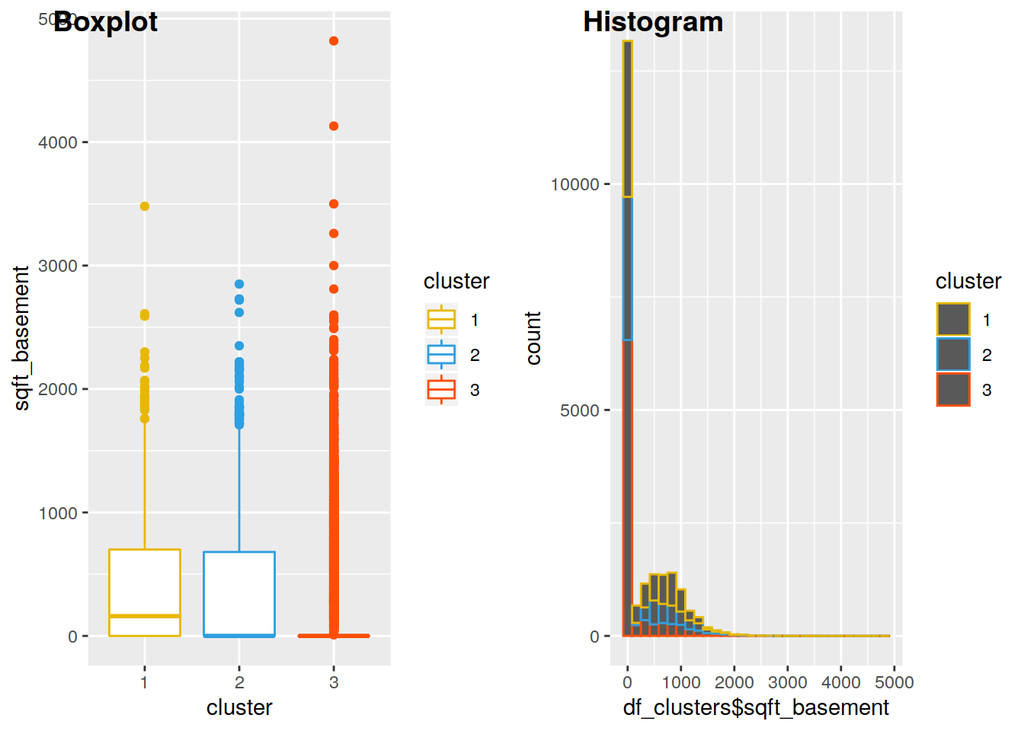

```r
my3cols <- c("#E7B800", "#2E9FDF", "#FC4E07")
df_clusters$cluster <- as.factor(df_clusters$cluster)

pBoxPlot <- ggplot(df_clusters, aes(x = cluster, y = sqft_basement))
bxp <- pBoxPlot + geom_boxplot(aes(color = cluster)) +
  scale_color_manual(values = my3cols)

geomHist <- ggplot(data=df_clusters, aes(df_clusters$sqft_basement))

gh <- geomHist + geom_histogram(aes(color = cluster)) +
      scale_color_manual(values = my3cols)

figure <- ggarrange(bxp, gh,
                    labels = c("Boxplot", "Histogram"),
                    ncol = 2, nrow = 1)
figure
```

**Estudio de la variable “yr_built” (año de construcción de la vivienda).**

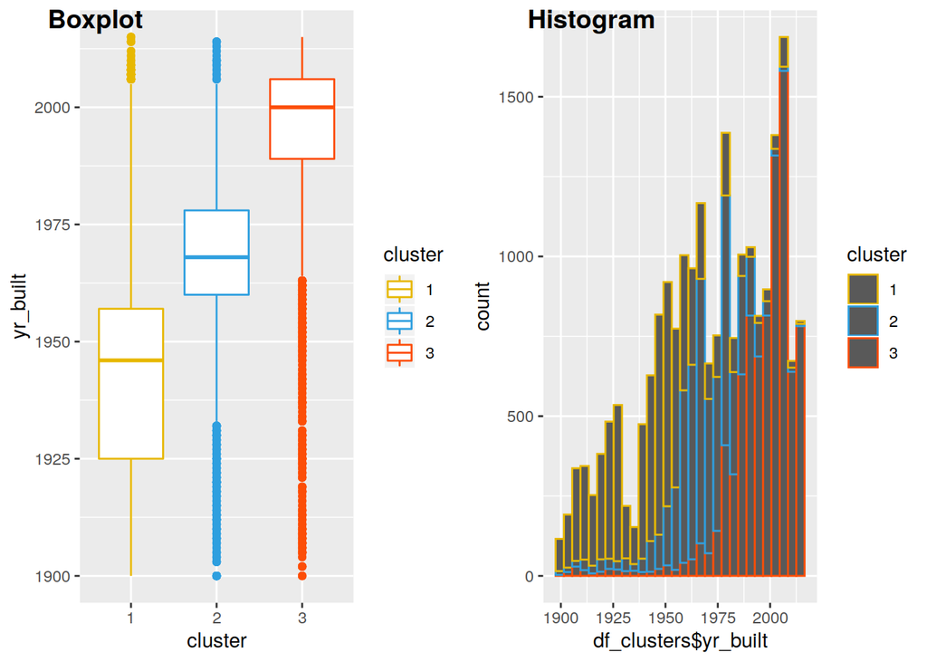

```r
my3cols <- c("#E7B800", "#2E9FDF", "#FC4E07")
df_clusters$cluster <- as.factor(df_clusters$cluster)

pBoxPlot <- ggplot(df_clusters, aes(x = cluster, y = yr_built))
bxp <- pBoxPlot + geom_boxplot(aes(color = cluster)) +
  scale_color_manual(values = my3cols)

geomHist <- ggplot(data=df_clusters, aes(df_clusters$yr_built))

gh <- geomHist + geom_histogram(aes(color = cluster)) +
      scale_color_manual(values = my3cols)

figure <- ggarrange(bxp, gh,
                    labels = c("Boxplot", "Histogram"),
                    ncol = 2, nrow = 1)
figure
```

**Estudio de la variable “yr_renovated” (año de renovación de la vivienda).**

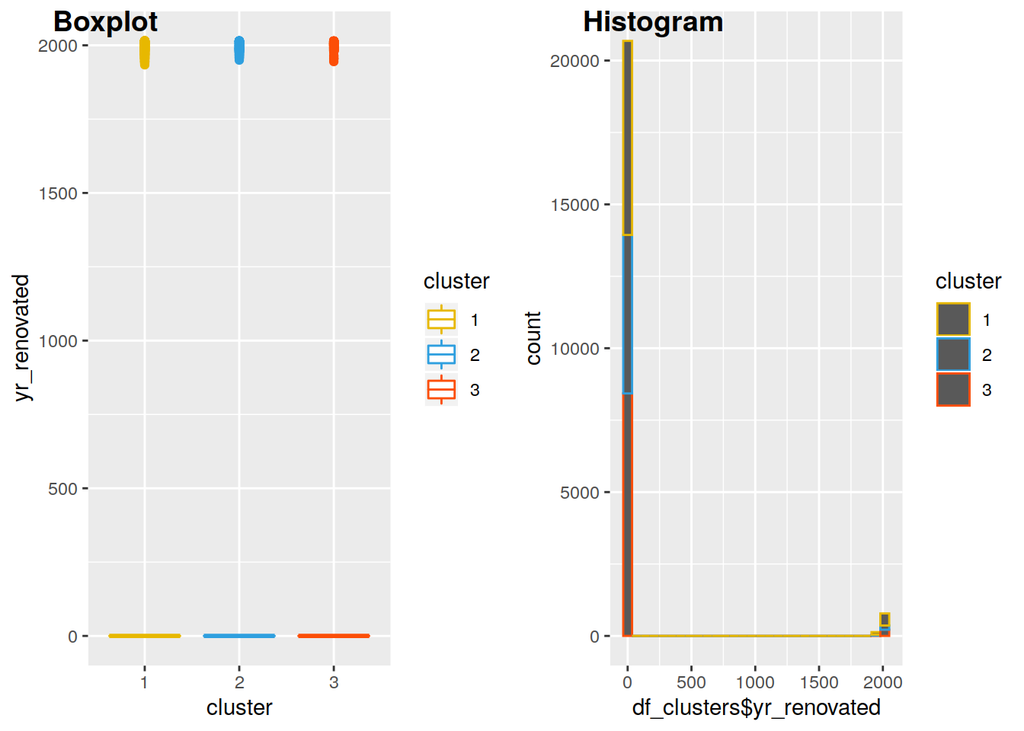

```r
my3cols <- c("#E7B800", "#2E9FDF", "#FC4E07")
df_clusters$cluster <- as.factor(df_clusters$cluster)

pBoxPlot <- ggplot(df_clusters, aes(x = cluster, y = yr_renovated))
bxp <- pBoxPlot + geom_boxplot(aes(color = cluster)) +
  scale_color_manual(values = my3cols)

geomHist <- ggplot(data=df_clusters, aes(df_clusters$yr_renovated))

gh <- geomHist + geom_histogram(aes(color = cluster)) +
      scale_color_manual(values = my3cols)

figure <- ggarrange(bxp, gh,
                    labels = c("Boxplot", "Histogram"),
                    ncol = 2, nrow = 1)
figure
```

### B. Analisis univariante cualitativo

**Estudio de la variable “date” (fecha de venta de la vivienda):** Dado que el objetivo de la práctica es poder predecir el precio de la vivienda, sería interesante para nuestro modelo separar esta variable en mes y año ya que el precio de venta se puede ver influido por la estación y por el año en el que se realizó la venta en funcion de los clusters.

Limites de las fechas para los clusters y diagramas de barras

```r
dates_1 = data.frame(date_1 = as.Date(cluster_1$date,"%m/%d/%Y"))
cluster_1$dates_m = format(dates_1,"%m")
cluster_1$dates_y = format(dates_1,"%Y")

dates_2 = data.frame(date_2 = as.Date(cluster_2$date,"%m/%d/%Y"))
cluster_2$dates_m = format(dates_2,"%m")
cluster_2$dates_y = format(dates_2,"%Y")

dates_3 = data.frame(date_3 = as.Date(cluster_3$date,"%m/%d/%Y"))
cluster_3$dates_m = format(dates_3,"%m")
cluster_3$dates_y = format(dates_3,"%Y")


# Límites del campo date
dates_1 %>% summarise(min = min(date_1), max = max(date_1))
```

```
##          min        max
## 1 2014-05-02 2015-05-27
```

```r
dates_2 %>% summarise(min = min(date_2), max = max(date_2))
```

```
##          min        max
## 1 2014-05-02 2015-05-15
```

```r
dates_3 %>% summarise(min = min(date_3), max = max(date_3))
```

```
##          min        max
## 1 2014-05-02 2015-05-14
```

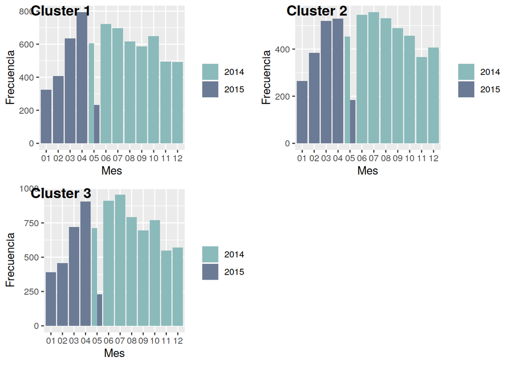

```r
# Tablas de frecuencias en función al mes y al año
#table(cluster_1$dates_y) %>% kable(., col.names = c('Años', 'Frecuencia'))
#table(cluster_1$dates_m) %>% kable(., col.names = c('Meses', 'Frecuencia'))

# Diagrama de barras con los meses del año y el número de viviendas vendidas
td_1 <- p_barras2(cluster_1, cluster_1$dates_m, cluster_1$dates_y, xlab = 'Mes')
td_2 <- p_barras2(cluster_2, cluster_2$dates_m, cluster_2$dates_y, xlab = 'Mes')
td_3 <- p_barras2(cluster_3, cluster_3$dates_m, cluster_3$dates_y, xlab = 'Mes')

figure <- ggarrange(td_1, td_2, td_3,
                    labels = c("Cluster 1", "Cluster 2","Cluster 3"),
                    #scale_color_manual(values = my3cols),
                    ncol = 2, nrow = 2)
figure
```

**Estudio de la variable “bedrooms” (Número de habitaciones por vivienda):**

```r
var_bedrooms_1 = cluster_1$bedrooms
var_bedrooms_2 = cluster_2$bedrooms
var_bedrooms_3 = cluster_3$bedrooms
name_1 = "cluster_1 bedrooms"
name_2 = "cluster_2 bedrooms"
name_3 = "cluster_3 bedrooms"

my3cols <- c("#E7B800", "#2E9FDF", "#FC4E07")

# Tablas de frecuencias en función al mes y al año
summary(var_bedrooms_1)
```

```
##    Min. 1st Qu.  Median    Mean 3rd Qu.    Max.
##   1.000   2.000   3.000   3.111   4.000  33.000
```

```r
summary(var_bedrooms_2)
```

```
##    Min. 1st Qu.  Median    Mean 3rd Qu.    Max.
##   1.000   3.000   3.000   3.345   4.000   8.000
```

```r
summary(var_bedrooms_3)
```

```
##    Min. 1st Qu.  Median    Mean 3rd Qu.    Max.
##   1.000   3.000   4.000   3.611   4.000  11.000
```

```
## $`1`
```

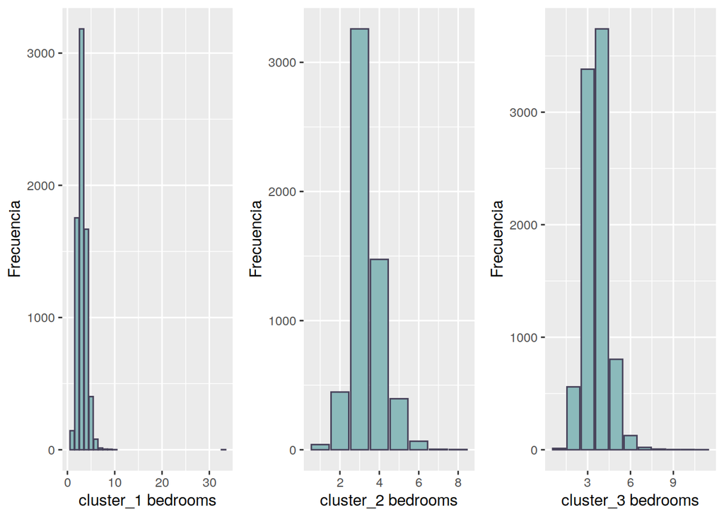

```
##
## $`2`
```

```
##
## attr(,"class")
## [1] "list"      "ggarrange"
```

```r
# Diagrama de barras con los meses del año y el número de viviendas vendidas
pb1 <- p_barras(cluster_1, var_bedrooms_1, xlab = name_1)
pb2 <- p_barras(cluster_2, var_bedrooms_2, xlab = name_2)
pb3 <- p_barras(cluster_3, var_bedrooms_3, xlab = name_3)

figure <- ggarrange(pb1, pb2, pb3,
                    #labels = c("Boxplot", "Histogram","pepe"),
                    scale_color_manual(values = my3cols),
                    ncol = 3, nrow = 1)
figure
```

**Estudio de la variable “bathrooms” (Número de baños/aseos por vivienda):**

Cluster 1

```r
var_bathrooms_1 = cluster_1$bathrooms
var_bathrooms_2 = cluster_2$bathrooms
var_bathrooms_3 = cluster_3$bathrooms
name_1 = "cluster_1 bathrooms"
name_2 = "cluster_2 bathrooms"
name_3 = "cluster_3 bathrooms"

my3cols <- c("#E7B800", "#2E9FDF", "#FC4E07")

# Tablas de frecuencias en función al mes y al año
summary(var_bathrooms_1)
```

```
##    Min. 1st Qu.  Median    Mean 3rd Qu.    Max.
##   0.500   1.000   1.750   1.663   2.000   8.000
```

```r
summary(var_bathrooms_2)
```

```
##    Min. 1st Qu.  Median    Mean 3rd Qu.    Max.
##   0.750   1.500   1.750   1.851   2.250   5.500
```

```r
summary(var_bathrooms_3)
```

```
##    Min. 1st Qu.  Median    Mean 3rd Qu.    Max.
##   0.500   2.500   2.500   2.669   2.750   8.000
```

```
## $`1`
```

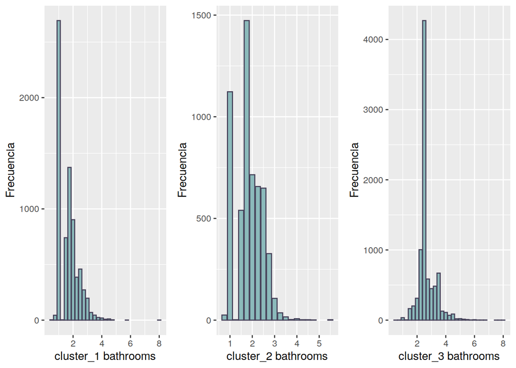

```
##
## $`2`
```

```
##
## attr(,"class")
## [1] "list"      "ggarrange"
```

```r
# Diagrama de barras con los meses del año y el número de viviendas vendidas
pb1 <- p_barras(cluster_1, var_bathrooms_1, xlab = name_1)
pb2 <- p_barras(cluster_2, var_bathrooms_2, xlab = name_2)
pb3 <- p_barras(cluster_3, var_bathrooms_3, xlab = name_3)

figure <- ggarrange(pb1, pb2, pb3,
                    #labels = c("Boxplot", "Histogram","pepe"),
                    scale_color_manual(values = my3cols),
                    ncol = 3, nrow = 1)
figure
```

**Estudio de la variable “floors” (Número de plantas por vivienda):**

```r
var_floors_1 = cluster_1$floors
var_floors_2 = cluster_2$floors
var_floors_3 = cluster_3$floors
name_1 = "cluster_1 floors"
name_2 = "cluster_2 floors"
name_3 = "cluster_3 floors"

my3cols <- c("#E7B800", "#2E9FDF", "#FC4E07")

# Tablas de frecuencias en función al mes y al año
summary(var_floors_1)
```

```
##    Min. 1st Qu.  Median    Mean 3rd Qu.    Max.
##    1.00    1.00    1.00    1.22    1.50    3.00
```

```r
summary(var_floors_2)
```

```
##    Min. 1st Qu.  Median    Mean 3rd Qu.    Max.
##   1.000   1.000   1.000   1.068   1.000   2.500
```

```r
summary(var_floors_3)
```

```
##    Min. 1st Qu.  Median    Mean 3rd Qu.    Max.
##   1.000   2.000   2.000   2.004   2.000   3.500
```

```
## $`1`
```

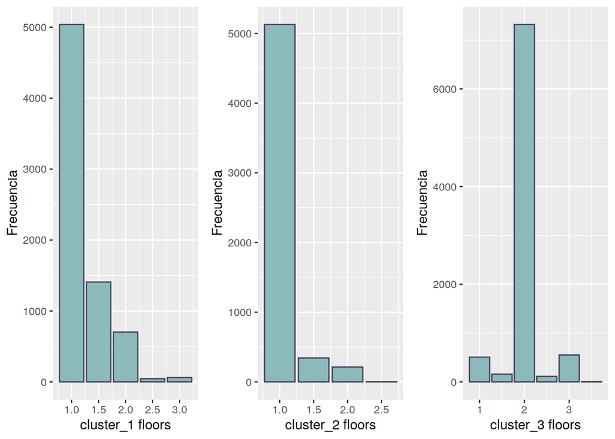

```
##
## $`2`
```

```
##
## attr(,"class")
## [1] "list"      "ggarrange"
```

```r
# Diagrama de barras con los meses del año y el número de viviendas vendidas
pb1 <- p_barras(cluster_1, var_floors_1, xlab = name_1)
pb2 <- p_barras(cluster_2, var_floors_2, xlab = name_2)
pb3 <- p_barras(cluster_3, var_floors_3, xlab = name_3)

figure <- ggarrange(pb1, pb2, pb3,
                    #labels = c("Boxplot", "Histogram","pepe"),
                    scale_color_manual(values = my3cols),
                    ncol = 3, nrow = 1)
figure
```

**Estudio de la variable “waterfront” (viviendas frente a grandes masas de agua):**

Cluster 1:

```r
var_waterfront_1 = cluster_1$waterfront
var_waterfront_2 = cluster_2$waterfront
var_waterfront_3 = cluster_3$waterfront
name_1 = "cluster_1 waterfront"
name_2 = "cluster_2 waterfront"
name_3 = "cluster_3 waterfront"

my3cols <- c("#E7B800", "#2E9FDF", "#FC4E07")

# Tablas de frecuencias en función al mes y al año
summary(var_waterfront_1)
```

```
##    Min. 1st Qu.  Median    Mean 3rd Qu.    Max.
## 0.00000 0.00000 0.00000 0.00634 0.00000 1.00000
```

```r
summary(var_waterfront_2)
```

```
##     Min.  1st Qu.   Median     Mean  3rd Qu.     Max.
## 0.000000 0.000000 0.000000 0.006682 0.000000 1.000000
```

```r
summary(var_waterfront_3)
```

```
##     Min.  1st Qu.   Median     Mean  3rd Qu.     Max.
## 0.000000 0.000000 0.000000 0.009128 0.000000 1.000000
```

```
## $`1`
```

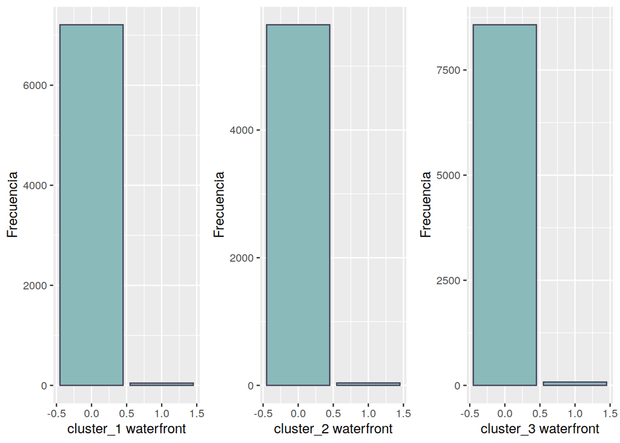

```
##
## $`2`
```

```
##
## attr(,"class")
## [1] "list"      "ggarrange"
```

```r
# Diagrama de barras con los meses del año y el número de viviendas vendidas
pb1 <- p_barras(cluster_1, var_waterfront_1, xlab = name_1)
pb2 <- p_barras(cluster_2, var_waterfront_2, xlab = name_2)
pb3 <- p_barras(cluster_3, var_waterfront_3, xlab = name_3)

figure <- ggarrange(pb1, pb2, pb3,
                    #labels = c("Boxplot", "Histogram","pepe"),
                    scale_color_manual(values = my3cols),
                    ncol = 3, nrow = 1)
figure
```

**Estudio de la variable “view” (número de visitas que ha recibido la vivienda):**

```r
var_view_1 = cluster_1$view
var_view_2 = cluster_2$view
var_view_3 = cluster_3$view
name_1 = "cluster_1 view"
name_2 = "cluster_2 view"
name_3 = "cluster_3 view"

my3cols <- c("#E7B800", "#2E9FDF", "#FC4E07")

# Tablas de frecuencias en función al mes y al año
summary(var_view_1)
```

```
##    Min. 1st Qu.  Median    Mean 3rd Qu.    Max.
##  0.0000  0.0000  0.0000  0.2571  0.0000  4.0000
```

```r
summary(var_view_2)
```

```
##    Min. 1st Qu.  Median    Mean 3rd Qu.    Max.
##  0.0000  0.0000  0.0000  0.1721  0.0000  4.0000
```

```r
summary(var_view_3)
```

```
##    Min. 1st Qu.  Median    Mean 3rd Qu.    Max.
##   0.000   0.000   0.000   0.256   0.000   4.000
```

```
## $`1`
```

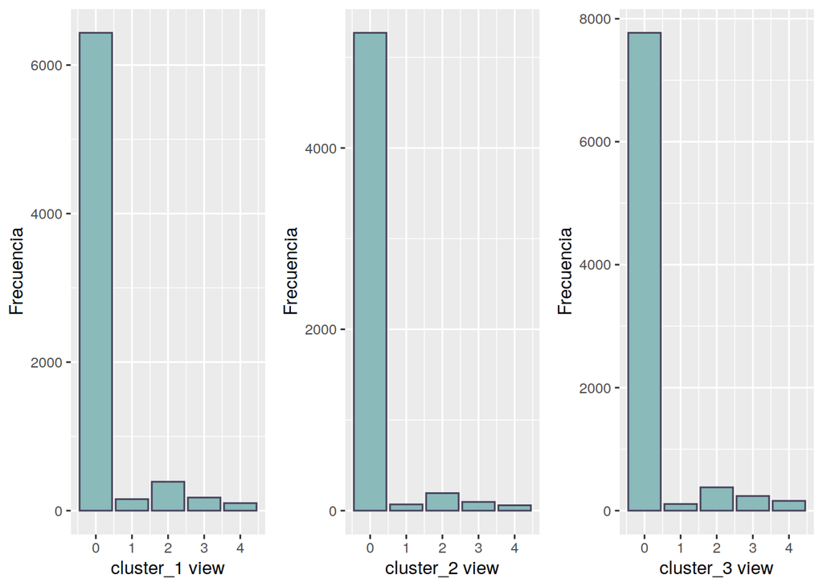

```
##
## $`2`
```

```
##
## attr(,"class")
## [1] "list"      "ggarrange"
```

```r
# Diagrama de barras con los meses del año y el número de viviendas vendidas
pb1 <- p_barras(cluster_1, var_view_1, xlab = name_1)
pb2 <- p_barras(cluster_2, var_view_2, xlab = name_2)
pb3 <- p_barras(cluster_3, var_view_3, xlab = name_3)

figure <- ggarrange(pb1, pb2, pb3,
                    #labels = c("Boxplot", "Histogram","pepe"),
                    scale_color_manual(values = my3cols),
                    ncol = 3, nrow = 1)
figure
```

**Estudio de la variable “condition” (estado de la vivienda del 1 al 5):**

Cluster 1:

```r
var_condition_1 = cluster_1$condition
var_condition_2 = cluster_2$condition
var_condition_3 = cluster_3$condition
name_1 = "cluster_1 condition"
name_2 = "cluster_2 condition"
name_3 = "cluster_3 condition"

my3cols <- c("#E7B800", "#2E9FDF", "#FC4E07")

# Tablas de frecuencias en función al mes y al año
summary(var_condition_1)
```

```
##    Min. 1st Qu.  Median    Mean 3rd Qu.    Max.
##    1.00    3.00    3.00    3.47    4.00    5.00
```

```r
summary(var_condition_2)
```

```
##    Min. 1st Qu.  Median    Mean 3rd Qu.    Max.
##   1.000   3.000   4.000   3.775   4.000   5.000
```

```r
summary(var_condition_3)
```

```
##    Min. 1st Qu.  Median    Mean 3rd Qu.    Max.
##   2.000   3.000   3.000   3.119   3.000   5.000
```

```
## $`1`
```

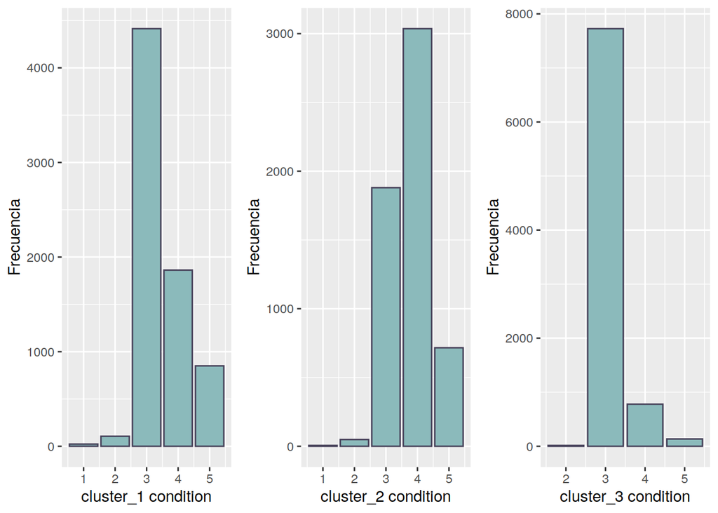

```
##
## $`2`
```

```
##
## attr(,"class")
## [1] "list"      "ggarrange"
```

```r
# Diagrama de barras con los meses del año y el número de viviendas vendidas
pb1 <- p_barras(cluster_1, var_condition_1, xlab = name_1)
pb2 <- p_barras(cluster_2, var_condition_2, xlab = name_2)
pb3 <- p_barras(cluster_3, var_condition_3, xlab = name_3)

figure <- ggarrange(pb1, pb2, pb3,
                    #labels = c("Boxplot", "Histogram","pepe"),
                    scale_color_manual(values = my3cols),
                    ncol = 3, nrow = 1)
figure
```

**Estudio de la variable “grade” (nota general de la vivienda del 1 al 13):**

```r
var_grade_1 = cluster_1$grade
var_grade_2 = cluster_2$grade
var_grade_3 = cluster_3$grade
name_1 = "cluster_1 grade"
name_2 = "cluster_2 grade"
name_3 = "cluster_3 grade"

my3cols <- c("#E7B800", "#2E9FDF", "#FC4E07")

# Tablas de frecuencias en función al mes y al año
summary(var_grade_1)
```

```
##    Min. 1st Qu.  Median    Mean 3rd Qu.    Max.
##   4.000   7.000   7.000   7.065   7.000  13.000
```

```r
summary(var_grade_2)
```

```
##    Min. 1st Qu.  Median    Mean 3rd Qu.    Max.
##    3.00    7.00    7.00    7.19    8.00   13.00
```

```r
summary(var_grade_3)
```

```
##    Min. 1st Qu.  Median    Mean 3rd Qu.    Max.
##   5.000   8.000   8.000   8.463   9.000  13.000
```

```
## $`1`
```

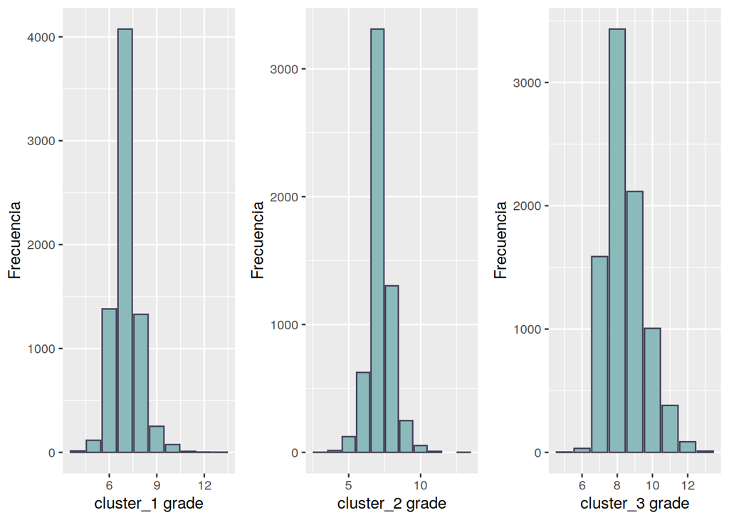

```
##
## $`2`
```

```
##
## attr(,"class")
## [1] "list"      "ggarrange"
```

```r
# Diagrama de barras con los meses del año y el número de viviendas vendidas
pb1 <- p_barras(cluster_1, var_grade_1, xlab = name_1)
pb2 <- p_barras(cluster_2, var_grade_2, xlab = name_2)
pb3 <- p_barras(cluster_3, var_grade_3, xlab = name_3)

figure <- ggarrange(pb1, pb2, pb3,
                    #labels = c("Boxplot", "Histogram","pepe"),
                    scale_color_manual(values = my3cols),
                    ncol = 3, nrow = 1)
figure
```

**Estudio de la variable “zipcode” (código postal):**

```r
var_zipcode_1 = cluster_1$zipcode
var_zipcode_2 = cluster_2$zipcode
var_zipcode_3 = cluster_3$zipcode
name_1 = "cluster_1 zipcode"
name_2 = "cluster_2 zipcode"
name_3 = "cluster_3 zipcode"

my3cols <- c("#E7B800", "#2E9FDF", "#FC4E07")

# Tablas de frecuencias en función al mes y al año
summary(var_zipcode_1)
```

```
##    Min. 1st Qu.  Median    Mean 3rd Qu.    Max.
##   98003   98109   98119   98126   98146   98199
```

```r
summary(var_zipcode_2)
```

```
##    Min. 1st Qu.  Median    Mean 3rd Qu.    Max.
##   98001   98010   98033   98039   98055   98199
```

```r
summary(var_zipcode_3)
```

```
##    Min. 1st Qu.  Median    Mean 3rd Qu.    Max.
##   98001   98030   98053   98063   98092   98199
```

```
## $`1`
```

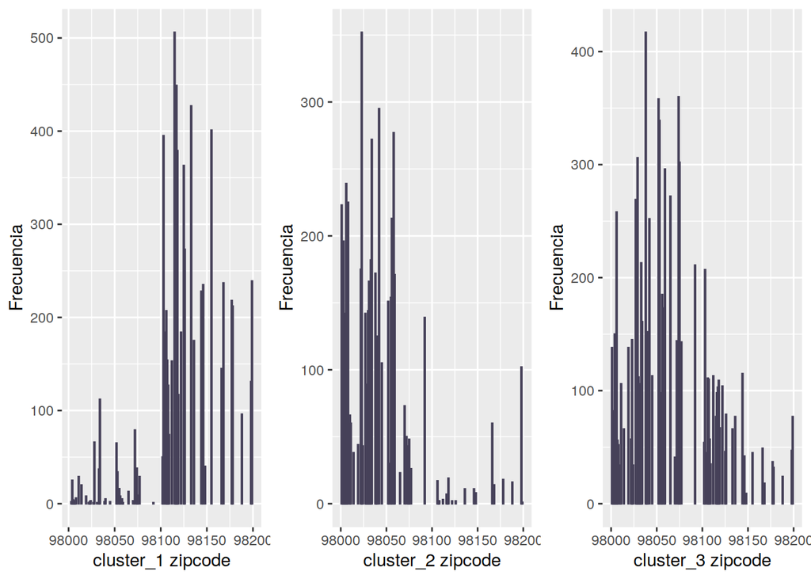

```
##
## $`2`
```

```
##
## attr(,"class")
## [1] "list"      "ggarrange"
```

```r
# Diagrama de barras con los meses del año y el número de viviendas vendidas
pb1 <- p_barras(cluster_1, var_zipcode_1, xlab = name_1)
pb2 <- p_barras(cluster_2, var_zipcode_2, xlab = name_2)
pb3 <- p_barras(cluster_3, var_zipcode_3, xlab = name_3)

figure <- ggarrange(pb1, pb2, pb3,
                    #labels = c("Boxplot", "Histogram","pepe"),
                    scale_color_manual(values = my3cols),
                    ncol = 3, nrow = 1)
figure
```

### c. Análisis multivariante cualitativo

**Estudio de la variable “bedrooms” (número de habitaciones por vivienda):**

```r
old = "bedrooms"
new = "cat_bedrooms"

#categorizamos la variable y mostramos su tabla de frecuencias
cluster_1[[new]] = cut2(cluster_1[[old]], g=4)
table(cluster_1[[new]])
```

```
##
## [1, 3)      3      4 [5,33]
##   1898   3183   1668    506
```

```r
cluster_2[[new]] = cut2(cluster_2[[old]], g=4)
table(cluster_2[[new]])
```

```
##
## [1,4)     4 [5,8]
##  3746  1474   467
```

```r
cluster_3[[new]] = cut2(cluster_3[[old]], g=4)
table(cluster_3[[new]])
```

```
##
## [1, 4)      4 [5,11]
##   3953   3740    962
```

```
## $`1`
```

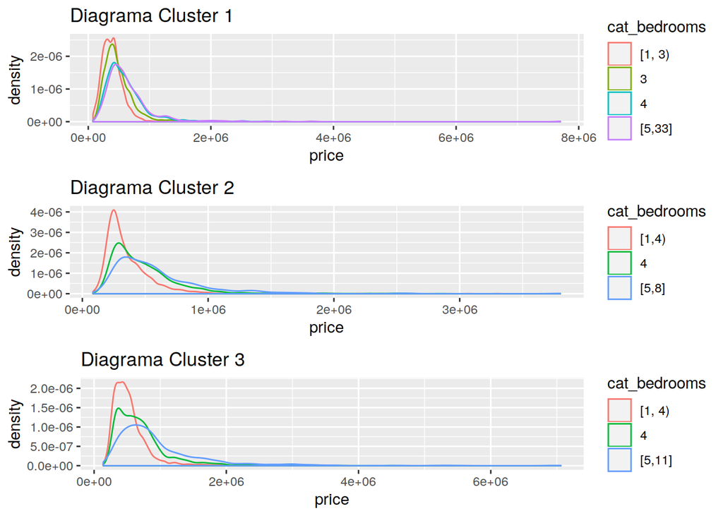

```
##
## $`2`
```

```
##
## attr(,"class")
## [1] "list"      "ggarrange"
```

```r
#visualización de los datos categorizados con respecto a la variable "price"
pd1 <- p_densidad(cluster_1, "Diagrama Cluster 1",new)
pd2 <- p_densidad(cluster_2, "Diagrama Cluster 2",new)
pd3 <- p_densidad(cluster_3, "Diagrama Cluster 3",new)

figure <- ggarrange(pd1, pd2, pd3,
                    #labels = c("Cluster 1", "Cluster 2","Cluster 3"),
                    scale_color_manual(values = my3cols),
                    ncol = 1, nrow = 3)
figure
```

**Estudio de la variable “bathrooms” (número de baños por vivienda):**

```r
old = "bathrooms"
new = "cat_bathrooms"

#categorizamos la variable y mostramos su tabla de frecuencias
cluster_1[[new]] = cut2(cluster_1[[old]], g=4)
table(cluster_1[[new]])
```

```
##
## [0.50,1.25) [1.25,2.00)        2.00 [2.25,8.00]
##        2740        2117         903        1495
```

```r
cluster_2[[new]] = cut2(cluster_2[[old]], g=4)
table(cluster_2[[new]])
```

```
##
## [0.75,1.75)        1.75 [2.00,2.50) [2.50,5.50]
##        1690        1473        1372        1152
```

```r
cluster_3[[new]] = cut2(cluster_3[[old]], g=4)
table(cluster_3[[new]])
```

```
##
## [0.50,2.75)        2.75 [3.00,8.00]
##        5993         586        2076
```

```
## $`1`
```

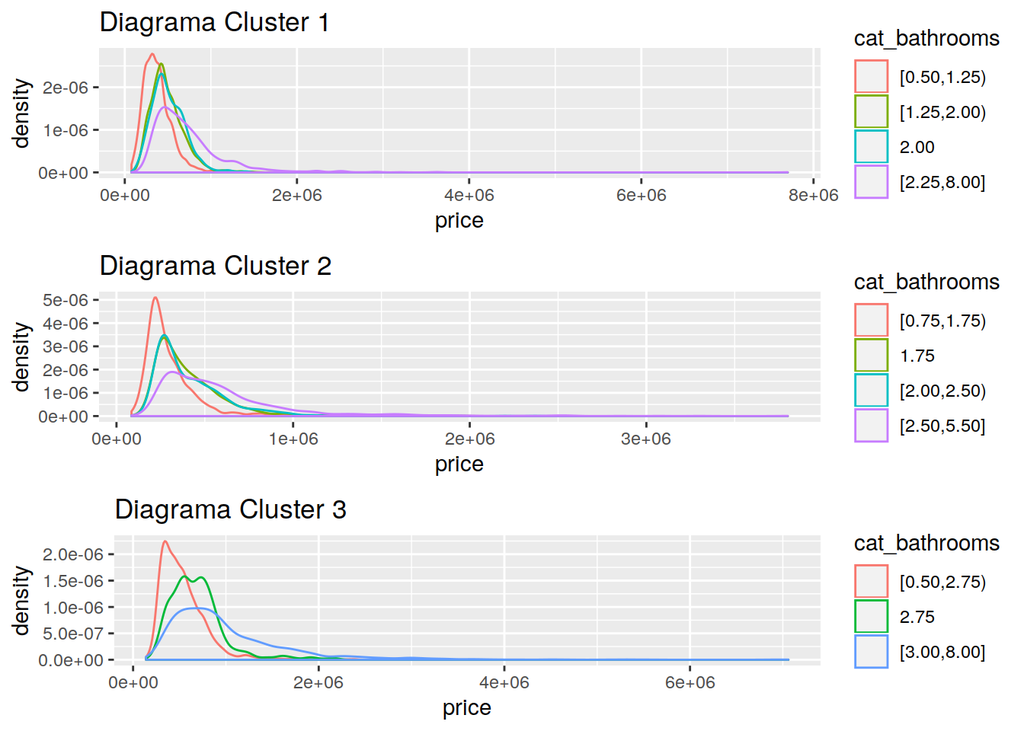

```
##
## $`2`
```

```
##
## attr(,"class")
## [1] "list"      "ggarrange"
```

```r
#visualización de los datos categorizados con respecto a la variable "price"
pd1 <- p_densidad(cluster_1, "Diagrama Cluster 1",new)
pd2 <- p_densidad(cluster_2, "Diagrama Cluster 2",new)
pd3 <- p_densidad(cluster_3, "Diagrama Cluster 3",new)

figure <- ggarrange(pd1, pd2, pd3,
                    #labels = c("Cluster 1", "Cluster 2","Cluster 3"),
                    scale_color_manual(values = my3cols),
                    ncol = 1, nrow = 3)
figure
```

**Estudio de la variable “floors” (número de plantas por vivienda):**

```r
old = "floors"
new = "cat_floors"

#categorizamos la variable y mostramos su tabla de frecuencias
cluster_1[[new]] = cut2(cluster_1[[old]], g=4)
table(cluster_1[[new]])
```

```
##
##       1.0       1.5 [2.0,3.0]
##      5038      1408       809
```

```r
cluster_2[[new]] = cut2(cluster_2[[old]], g=4)
table(cluster_2[[new]])
```

```
##
##       1.0 [1.5,2.5]
##      5128       559
```

```r
cluster_3[[new]] = cut2(cluster_3[[old]], g=4)
table(cluster_3[[new]])
```

```
##
## [1.0,2.5) [2.5,3.5]
##      7985       670
```

```
## $`1`
```

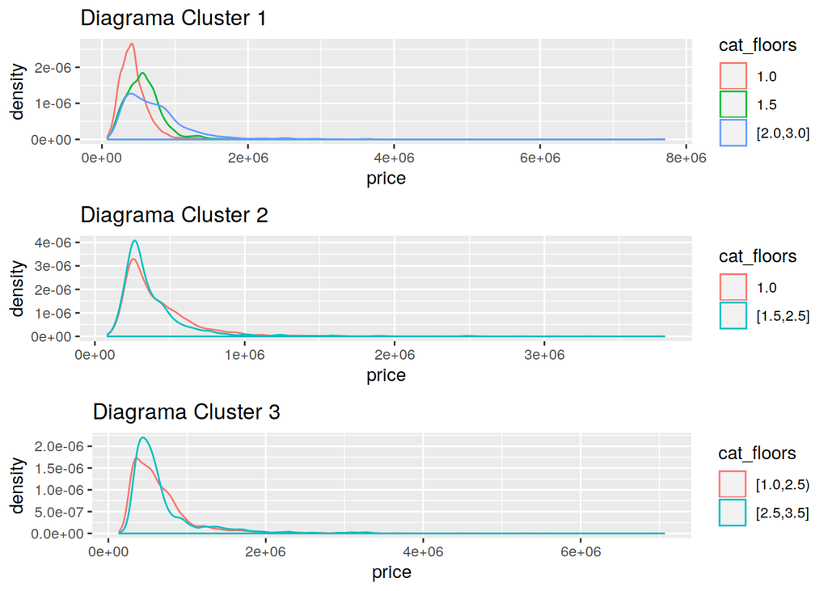

```
##
## $`2`
```

```
##
## attr(,"class")
## [1] "list"      "ggarrange"
```

```r
#visualización de los datos categorizados con respecto a la variable "price"
pd1 <- p_densidad(cluster_1, "Diagrama Cluster 1",new)
pd2 <- p_densidad(cluster_2, "Diagrama Cluster 2",new)
pd3 <- p_densidad(cluster_3, "Diagrama Cluster 3",new)

figure <- ggarrange(pd1, pd2, pd3,
                    #labels = c("Cluster 1", "Cluster 2","Cluster 3"),
                    scale_color_manual(values = my3cols),
                    ncol = 1, nrow = 3)
figure
```

**Estudio de la variable “waterfront”:**

```
## $`1`
```

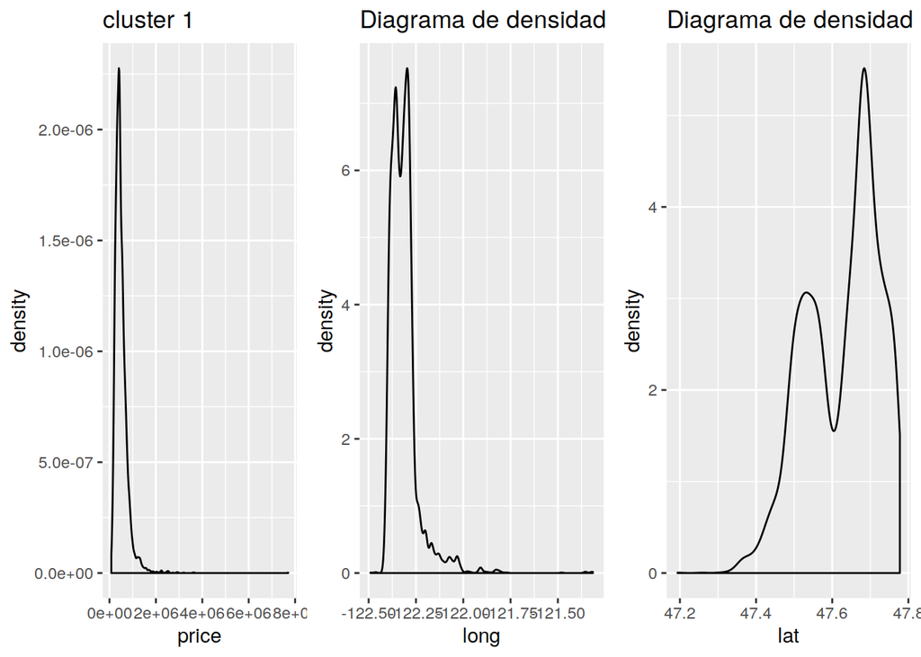

```
##
## $`2`
```

```
##
## attr(,"class")
## [1] "list"      "ggarrange"
```

```r
name = "waterfront"

#mostramos su tabla de frecuencias
#table(cluster_1[[name]])

#visualización de los datos categorizados con respecto a la variable "price"
pd_c1 = p_densidad(cluster_1, "cluster 1", name)
pd_c2 = p_densidad(cluster_2, "cluster 2", name)
pd_c3 = p_densidad(cluster_3, "cluster 3", name)

#visualización de los datos categorizados con respecto a la variable "long"
p1_c1 = p_densidad2(cluster_1, name, 'long')
p1_c2 = p_densidad2(cluster_2, name, 'long')
p1_c3 = p_densidad2(cluster_3, name, 'long')
#visualización de los datos categorizados con respecto a la variable "lat"
p2_c1 = p_densidad2(cluster_1, name, 'lat')
p2_c2 = p_densidad2(cluster_2, name, 'lat')
p2_c3 = p_densidad2(cluster_3, name, 'lat')

figure_c1 <- ggarrange(pd_c1, p1_c1, p2_c1,
                    #labels = c("Cluster 1", "Cluster 2","Cluster 3"),
                    scale_color_manual(values = my3cols),
                    ncol = 3, nrow = 1)
figure_c1
```

```
## $`1`
```

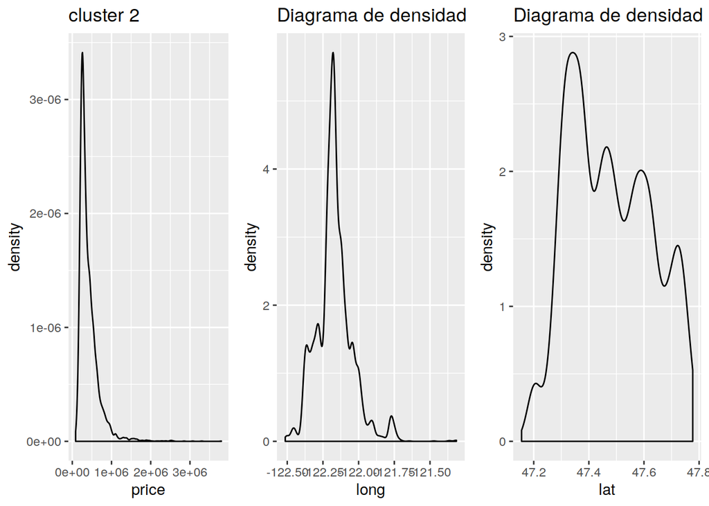

```
##
## $`2`
```

```
##
## attr(,"class")
## [1] "list"      "ggarrange"
```

```r
figure_c2 <- ggarrange(pd_c2, p1_c2, p2_c2,
                    #labels = c("Cluster 1", "Cluster 2","Cluster 3"),
                    scale_color_manual(values = my3cols),
                    ncol = 3, nrow = 1)
figure_c2
```

```
## $`1`
```

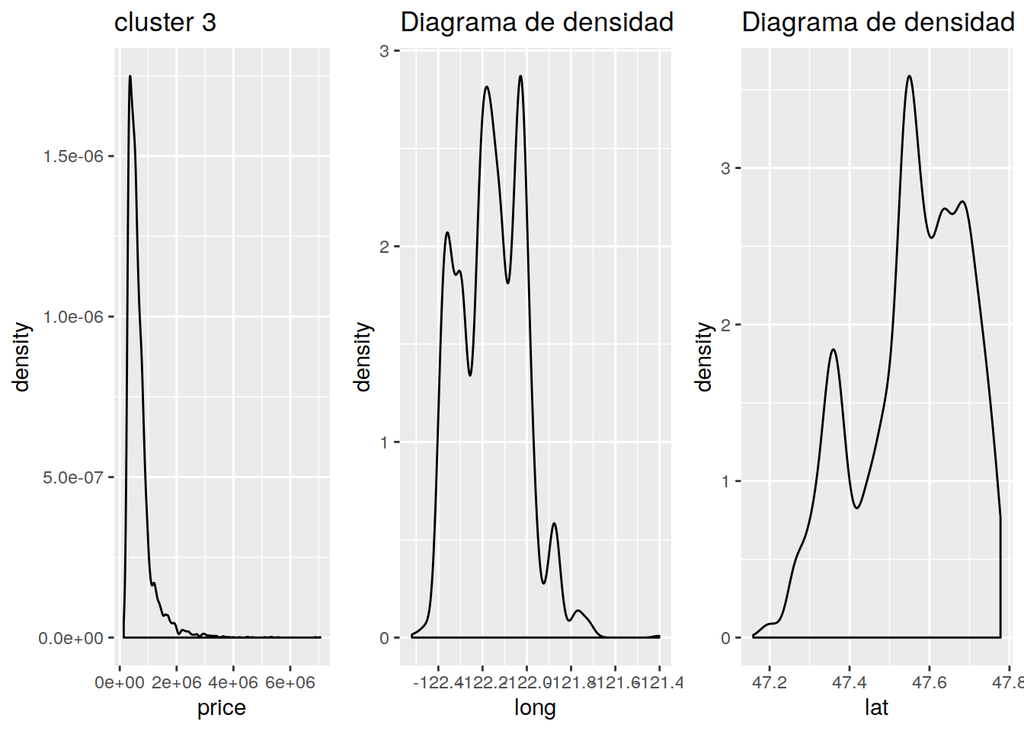

```
##
## $`2`
```

```
##
## attr(,"class")
## [1] "list"      "ggarrange"
```

```r
figure_c3 <- ggarrange(pd_c3, p1_c3, p2_c3,
                    #labels = c("Cluster 1", "Cluster 2","Cluster 3"),
                    scale_color_manual(values = my3cols),
                    ncol = 3, nrow = 1)
figure_c3
```

**Estudio de la variable “view”:**

```r
old = "view"
new = "cat_view"

#categorizamos la variable y mostramos su tabla de frecuencias
cluster_1[[new]] = cut2(cluster_1[[old]], g=3)
table(cluster_1[[new]])
```

```
##
##     0 [1,4]
##  6434   821
```

```r
cluster_2[[new]] = cut2(cluster_2[[old]], g=3)
table(cluster_2[[new]])
```

```
##
##     0 [1,4]
##  5270   417
```

```r
cluster_3[[new]] = cut2(cluster_3[[old]], g=3)
table(cluster_3[[new]])
```

```
##
##     0 [1,4]
##  7771   884
```

```
## $`1`
```

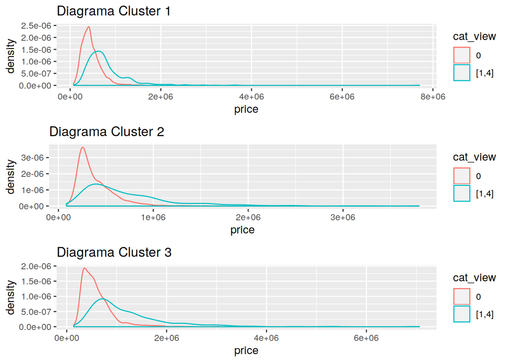

```
##
## $`2`
```

```
##
## attr(,"class")
## [1] "list"      "ggarrange"
```

```r
#visualización de los datos categorizados con respecto a la variable "price"
pd1 <- p_densidad(cluster_1, "Diagrama Cluster 1",new)
pd2 <- p_densidad(cluster_2, "Diagrama Cluster 2",new)
pd3 <- p_densidad(cluster_3, "Diagrama Cluster 3",new)

figure <- ggarrange(pd1, pd2, pd3,
                    #labels = c("Cluster 1", "Cluster 2","Cluster 3"),
                    scale_color_manual(values = my3cols),
                    ncol = 1, nrow = 3)
figure
```

**Estudio de la variable “condition”:**

```r
old = "condition"
new = "cat_condition"

#categorizamos la variable y mostramos su tabla de frecuencias
cluster_1[[new]] = cut2(cluster_1[[old]], g=3)
table(cluster_1[[new]])
```

```
##
## [1,4)     4     5
##  4543  1862   850
```

```r
cluster_2[[new]] = cut2(cluster_2[[old]], g=3)
table(cluster_2[[new]])
```

```
##
## [1,4)     4     5
##  1935  3036   716
```

```r
cluster_3[[new]] = cut2(cluster_3[[old]], g=3)
table(cluster_3[[new]])
```

```
##
## [2,4) [4,5]
##  7741   914
```

```
## $`1`
```

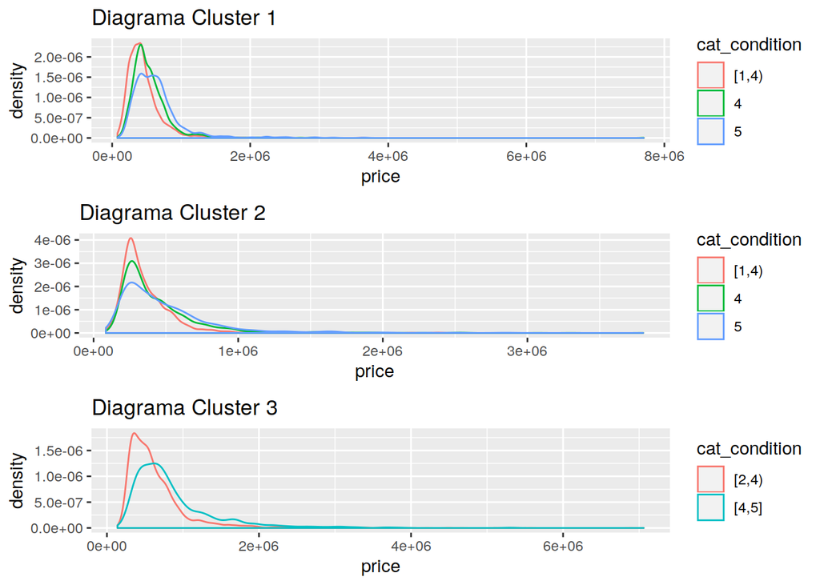

```
##
## $`2`
```

```
##
## attr(,"class")
## [1] "list"      "ggarrange"
```

```r
#visualización de los datos categorizados con respecto a la variable "price"
pd1 <- p_densidad(cluster_1, "Diagrama Cluster 1",new)
pd2 <- p_densidad(cluster_2, "Diagrama Cluster 2",new)
pd3 <- p_densidad(cluster_3, "Diagrama Cluster 3",new)

figure <- ggarrange(pd1, pd2, pd3,
                    #labels = c("Cluster 1", "Cluster 2","Cluster 3"),
                    scale_color_manual(values = my3cols),
                    ncol = 1, nrow = 3)
figure
```

**Estudio de la variable “grade”:**

```r
old = "grade"
new = "cat_grade"

#corrección reemplazando el string s por un "NA"
cluster_1[[old]][cluster_1[[old]] == "s"] <- NA
cluster_1[[old]] = as.numeric(cluster_1[[old]])
cluster_2[[old]][cluster_2[[old]] == "s"] <- NA
cluster_2[[old]] = as.numeric(cluster_2[[old]])
cluster_3[[old]][cluster_3[[old]] == "s"] <- NA
cluster_3[[old]] = as.numeric(cluster_3[[old]])


#categorizamos la variable y mostramos su tabla de frecuencias
cluster_1[[new]] = cut2(cluster_1[[old]], g=4)
table(cluster_1[[new]])
```

```
##
## [4, 8) [8,13]
##   5585   1670
```

```r
cluster_2[[new]] = cut2(cluster_2[[old]], g=4)
table(cluster_2[[new]])
```

```
##
## [3, 8)      8 [9,13]
##   4074   1303    310
```

```r
cluster_3[[new]] = cut2(cluster_3[[old]], g=4)
table(cluster_3[[new]])
```

```
##
## [ 5, 9)       9 [10,13]
##    5056    2116    1483
```

```
## $`1`
```

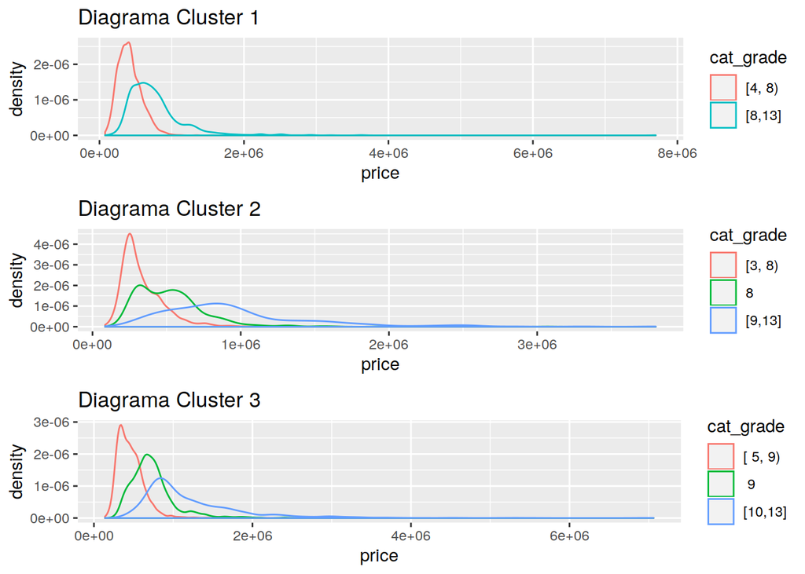

```
##
## $`2`
```

```
##
## attr(,"class")
## [1] "list"      "ggarrange"
```

```r
#visualización de los datos categorizados con respecto a la variable "price"
pd1 <- p_densidad(cluster_1, "Diagrama Cluster 1",new)
pd2 <- p_densidad(cluster_2, "Diagrama Cluster 2",new)
pd3 <- p_densidad(cluster_3, "Diagrama Cluster 3",new)

figure <- ggarrange(pd1, pd2, pd3,
                    #labels = c("Cluster 1", "Cluster 2","Cluster 3"),
                    scale_color_manual(values = my3cols),
                    ncol = 1, nrow = 3)
figure
```

**Estudio de la variable “zipcode” (código postal):**

```r
old = "zipcode"
new = "cat_zipcode"

#categorizamos la variable y mostramos su tabla de frecuencias
cluster_1[[new]] = cut2(cluster_1[[old]], g=3)
table(cluster_1[[new]])
```

```
##
## [98003,98116) [98116,98136) [98136,98199]
##          2481          2417          2357
```

```r
cluster_2[[new]] = cut2(cluster_2[[old]], g=3)
table(cluster_2[[new]])
```

```
##
## [98001,98024) [98024,98045) [98045,98199]
##          2114          1774          1799
```

```r
cluster_3[[new]] = cut2(cluster_3[[old]], g=3)
table(cluster_3[[new]])
```

```
##
## [98001,98039) [98039,98075) [98075,98199]
##          3131          2815          2709
```

```
## $`1`
```

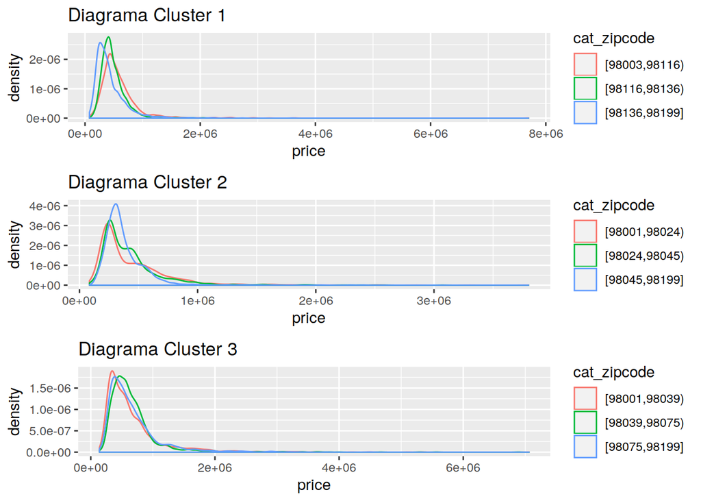

```
##
## $`2`
```

```
##
## attr(,"class")
## [1] "list"      "ggarrange"
```

```r
#visualización de los datos categorizados con respecto a la variable "price"
pd1 <- p_densidad(cluster_1, "Diagrama Cluster 1",new)
pd2 <- p_densidad(cluster_2, "Diagrama Cluster 2",new)
pd3 <- p_densidad(cluster_3, "Diagrama Cluster 3",new)

figure <- ggarrange(pd1, pd2, pd3,
                    #labels = c("Cluster 1", "Cluster 2","Cluster 3"),
                    scale_color_manual(values = my3cols),
                    ncol = 1, nrow = 3)
figure
```